# Case Study 3: Galeries Lafayette

UNIGE - GSEM - Advanced Data-Driven Decision Making

2023-04-29

Abstract

> *This analysis was prepared by Francisco Arrieta and Jonathan Edwards.*

# 1 Setup

```r
# options(scipen=999) #prevent scientific notation
# options(scipen=-999) #encourage scientific notation
options(scipen=0) #encourage scientific notation neutral?
```

## 1.1 libraries

```r
# modelling
library(psych) #factor analysis tools (PCA PAF)
library(lavaan) #causal analysis
library(lm.beta) # add standarized regression coeffs

# stats
library(nortest) #Kolmogorov-Smirnov-Test
library(corrplot) #correlation matrix plot
library(olsrr)  #VIF and Tolerance Values
library(pastecs) # provides function stat.desc
library(REdaS) #Bartelett's Test

# plotting & formatting
library(ggplot2) #better graphs
library(patchwork) # provides wrap_plots for multiplotting
# library(gridExtra) #provides multiplotting functionality
# library(ggpubr) #provides ggarrange for multiplotting (patchwork better though)
library(semPlot) #for visualization of path diagrams (SEM)
library(lavaanPlot) #for visualization of path diagrams (SEM)
# library(rcompanion)   #Histogram and Normal Curve
library(kableExtra) #makes nice tables

# generic
library(dplyr) #useful data manip functions like arrange, distinct, rename etc included in fpp3
library(stringr) # provides string manip functions like str_split_fixed
library(Hmisc) #describe function that describes features of dataframes
library(data.table) # creating and manipulating datatables
library(knitr) #rmarkdown tools not sure why useful
library(parameters) #get model outputs in table form (good for making tabs)
```

## 1.2 Load data

```r
survey <- read.csv("Case Study III_Structural Equation Modeling.csv")
labels <- read.csv("Variables and Labels_Galeries Lafayette.csv")

dim(survey)
```

```
## [1] 553  45
```

```r
head(labels)
```

```
##   Variable
## 1      Im1
## 2      Im2
## 3      Im3
## 4      Im4
## 5      Im5
## 6      Im6
##                                                                                    Label
## 1                       What do GLB represent from your point of view?  Large Assortment
## 2                     What do GLB represent from your point of view?  Assortment Variety
## 3      What do GLB represent from your point of view?  Artistic Decoration of Sales Area
## 4      What do GLB represent from your point of view?  Creative Decoration of Sales Area
## 5  What do GLB represent from your point of view?  Appealing Arrangement of Shop Windows
## 6                                 What do GLB represent from your point of view?  France
```

```r
#Make labels more readable
#create copy of label column without variable code
labels["Category"] <- sub("[^-]*\\s-","",labels[["Label"]])
# labels["Category"] <- sub(".*\\s-","",labels[["Label"]])
# labels

#split this new column (category) into category and short label
labels[c("Category","Label_short")] <- str_split_fixed(labels[["Category"]],"\\?\\s\\s|\\s-", n=2)
labels[20:25,]
```

```
##    Variable
## 20     Im20
## 21     Im21
## 22     Im22
## 23    C_CR1
## 24    C_CR2
## 25    C_CR3
##                                                                                                                                       Label
## 20                                                                        What do GLB represent from your point of view?  Relaxing Shopping
## 21                                                                  What do GLB represent from your point of view?  A Great Place to Stroll
## 22                                                                 What do GLB represent from your point of view?  Intimate Shop Atmosphere
## 23         C_COCRE1 -CO-CREATION -I would like to participate in an expert-workshop to improve the assortment of Galeries Lafayette Berlin.
## 24                                 C_COCRE2 -CO-CREATION -I would be available to take part in another survey at Galeries Lafayette Berlin.
## 25 C_COCRE3 -CO-CREATION -I would like to become a member of a customer group whose opinion is obtained for new products and major changes.
##                                          Category
## 20  What do GLB represent from your point of view
## 21  What do GLB represent from your point of view
## 22  What do GLB represent from your point of view
## 23                                    CO-CREATION
## 24                                    CO-CREATION
## 25                                    CO-CREATION
##                                                                                                          Label_short
## 20                                                                                                 Relaxing Shopping
## 21                                                                                           A Great Place to Stroll
## 22                                                                                          Intimate Shop Atmosphere
## 23         I would like to participate in an expert-workshop to improve the assortment of Galeries Lafayette Berlin.
## 24                                 I would be available to take part in another survey at Galeries Lafayette Berlin.
## 25 I would like to become a member of a customer group whose opinion is obtained for new products and major changes.
```

## 1.3 Clean and handle missing data

```r
# # omit all unanswered
# filter_all(survey, all_vars(. != 999))
# filter_all(survey, any_vars(. %in% c(999)))
#
# filter_all(select(survey,1:22,"SAT_1"), all_vars(. != 999))
# filter_all(select(survey,1:22,"SAT_1"), any_vars(. %in% c(999)))
#
# filter_all(data_img_EFA, all_vars(. != 999))
# filter_all(ges, any_vars(. %in% c(999)))
```

```r
# delete variables unused in analysis (see case study instructions):
survey <- survey |> select(-c("C_CR2", "SAT_P1", "SAT_P2", "SAT_P3", "SAT_P4", "SAT_P5", "SAT_P6", "TRU_1", "TRU_2", "TRU_3"))

# replace missing data (999) with NA
survey <- data.frame(sapply(survey,function(x) ifelse((x==999),NA,as.numeric(x))))
```

## 1.4 Explore Data

# 2 Dimensions by which Galeries Lafayette is perceived

## 2.1 ROUND 1: Exploratory factor analysis

### 2.1.1 Variable selection for EFA

```r
# excluded image variables (in the first round of EFA we don't exclude any image variables...)
exclude=c()

# the full survey data (includes dependent and independent variables) with excluded image variables (in this first round of EFA we don't exclude anything)
survey_excl_img <- survey |> select(-exclude)

# the data we will use for EFA (images)
data_img_EFA <- survey_excl_img[1:(22-length(exclude))]
```

### 2.1.2 handle missing data

```r
# delete missing data (delete listwise)
data_img_EFA <- na.omit(data_img_EFA)

dim(survey)
```

```
## [1] 553  35
```

```r
dim(survey_excl_img)
```

```
## [1] 553  35
```

```r
dim(data_img_EFA)
```

```
## [1] 385  22
```

### 2.1.3 Check adequacy of correlation Matrix

#### 2.1.3.1 correlation matrix

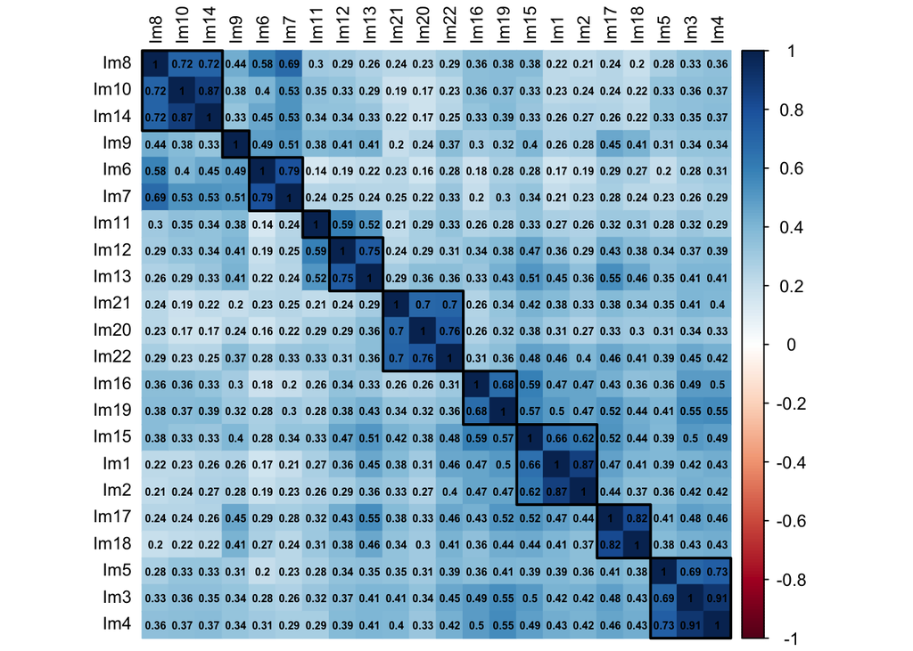

```r
#plot correlation matrix adjusting parameters to see previously identified groupings
corr_matrix <- cor(data_img_EFA)
corrplot(as.matrix(corr_matrix),
         method = "color", #col = c("white","white","white","white","white", "lightgrey", "darkgrey", "black"),
         order = "hclust", addrect = 10, rect.col="black", # rect.col="red",
         addCoef.col = 'black', number.cex = .5,
         tl.col ="black",
         tl.cex = 0.80,
         )
```

Variables to look out for going forward:

- Images 9 and 11 are alone
- Pairs of images: (17,18), cluster exclusively together, have a very high correlation and similar correlation profiles meaning we might only want to keep one of them. Similar comment to a lesser degree for (6,7) and (16,19).

#### 2.1.3.2 Bartlett’s Test

```r
bart_spher(data_img_EFA)
```

```
##  Bartlett's Test of Sphericity
##
## Call: bart_spher(x = data_img_EFA)
##
##      X2 = 6451.238
##      df = 231
## p-value < 2.22e-16
```

The Bartlett Test tests the hypothesis that the sample originates from a population, where all variables are uncorrelated. This would not be good for factor analysis, we want this hypothesis to be rejected meaning p-value < 5%.

In our case we see that it is indeed rejected and that the data is not uncorrelated.

#### 2.1.3.3 KMO

```r
KMOTEST=KMOS(data_img_EFA)
print(KMOTEST, sort=T)
```

```
##
## Kaiser-Meyer-Olkin Statistics
##
## Call: KMOS(x = data_img_EFA)
##
## Measures of Sampling Adequacy (MSA):
##       Im2       Im6       Im1      Im20      Im14      Im10       Im7       Im4
## 0.8224640 0.8224827 0.8244624 0.8266391 0.8267452 0.8285789 0.8448231 0.8542604
##      Im18       Im3      Im17      Im13      Im12      Im22      Im16      Im11
## 0.8550678 0.8640362 0.8644991 0.8722220 0.8789413 0.8793157 0.9092200 0.9113882
##      Im21       Im8       Im9      Im19       Im5      Im15
## 0.9149654 0.9300079 0.9380091 0.9400714 0.9546668 0.9647563
##
## KMO-Criterion: 0.8770975
```

The KMO of 0.8770975 is above 0.6 which indicates the data is well suited for factor anlysis.

#### 2.1.3.4 Anti-image Correlation

```r
MSA_list <- data.table("Item"=names(KMOTEST$MSA), "MSA"=as.numeric(KMOTEST$MSA))

#Display table
MSA_list<- MSA_list |>
  setorder(cols = "MSA")

MSA_list |>
  kable() |>
  kable_minimal() |>
  row_spec(which(MSA_list[,2]<0.5), bold = T, color = "white", background = "#78BE20")
```

| Item | MSA |
| --- | --- |
| Im2 | 0.8224640 |
| Im6 | 0.8224827 |
| Im1 | 0.8244624 |
| Im20 | 0.8266391 |
| Im14 | 0.8267452 |
| Im10 | 0.8285789 |
| Im7 | 0.8448231 |
| Im4 | 0.8542604 |
| Im18 | 0.8550678 |
| Im3 | 0.8640362 |
| Im17 | 0.8644991 |
| Im13 | 0.8722220 |
| Im12 | 0.8789413 |
| Im22 | 0.8793157 |
| Im16 | 0.9092200 |
| Im11 | 0.9113882 |
| Im21 | 0.9149654 |
| Im8 | 0.9300079 |
| Im9 | 0.9380091 |
| Im19 | 0.9400714 |
| Im5 | 0.9546668 |
| Im15 | 0.9647563 |

Variables with MSA values above 0.5 are suited for factor analysis. Presence of items with low MSA’s (<0.5) could also indicate that an important topic hasn’t been well covered in the questionnaire.

All variables have MSA above 0.5

### 2.1.4 Select method: PCA

#### 2.1.4.1 Extract factors

```r
EFA_PC0 <- psych::principal(data_img_EFA, rotate="varimax", scores=TRUE)
# note: by default number of factors = 1 if it is not specified
```

##### 2.1.4.1.1 Scree plot

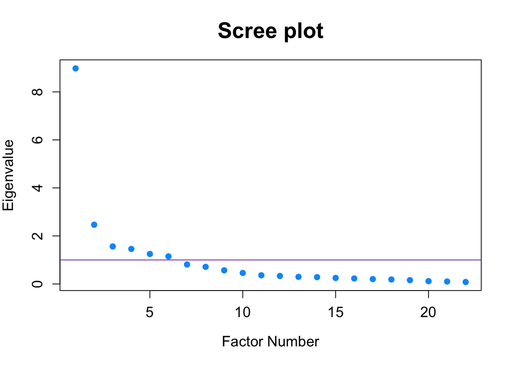

```r
#display Scree-plot
plot(EFA_PC0$values,xlab="Factor Number",
     ylab="Eigenvalue",
     main="Scree plot",
     cex.lab=1.2,
     cex.axis=1.2,
     cex.main=1.8,
     col = "#0099F8",
     pch = 19)
abline(h=1, col = "#7F35B2")
```

##### 2.1.4.1.2 Kaiser Criterion

```r
EFA_PC0_kaiser_nb <- length(which(EFA_PC0$values > 1))
EFA_PC0_kaiser_nb
```

```
## [1] 6
```

The Kaiser criterion suggests we should retain factors with eigenvalues bigger than 1.

There are 6 factors satisfying this condition.

##### 2.1.4.1.3 Total Variance Explained

```r
#calculate total variance (does not change if number of factors change)
EFA_PC0_EigenValue <- EFA_PC0$values
EFA_PC0_Variance <- EFA_PC0_EigenValue / ncol(data_img_EFA) * 100
EFA_PC0_SumVariance <- cumsum(EFA_PC0_EigenValue / ncol(data_img_EFA))
EFA_PC0_Total_Variance_Explained <- cbind("Factor number"=
                                            seq(1, length.out=length(EFA_PC0_EigenValue[EFA_PC0_EigenValue>0])),
                                          EigenValue = EFA_PC0_EigenValue[EFA_PC0_EigenValue>0],
                                          Variance = EFA_PC0_Variance[EFA_PC0_EigenValue>0],
                                          Total_Variance = EFA_PC0_SumVariance[EFA_PC0_EigenValue>0])
#display table
EFA_PC0_Total_Variance_Explained |>
  kable() |>
  kable_minimal()
```

| Factor number | EigenValue | Variance | Total_Variance |
| --- | --- | --- | --- |
| 1 | 8.9775864 | 40.8072107 | 0.4080721 |
| 2 | 2.4672638 | 11.2148355 | 0.5202205 |
| 3 | 1.5619592 | 7.0998144 | 0.5912186 |
| 4 | 1.4568388 | 6.6219948 | 0.6574386 |
| 5 | 1.2478517 | 5.6720533 | 0.7141591 |
| 6 | 1.1473375 | 5.2151705 | 0.7663108 |
| 7 | 0.8100993 | 3.6822696 | 0.8031335 |
| 8 | 0.7116130 | 3.2346046 | 0.8354795 |
| 9 | 0.5678552 | 2.5811600 | 0.8612911 |
| 10 | 0.4568442 | 2.0765645 | 0.8820568 |
| 11 | 0.3613996 | 1.6427257 | 0.8984840 |
| 12 | 0.3323475 | 1.5106703 | 0.9135907 |
| 13 | 0.2949972 | 1.3408963 | 0.9269997 |
| 14 | 0.2835170 | 1.2887137 | 0.9398868 |
| 15 | 0.2493639 | 1.1334721 | 0.9512216 |
| 16 | 0.2281106 | 1.0368663 | 0.9615902 |
| 17 | 0.2022522 | 0.9193284 | 0.9707835 |
| 18 | 0.1862414 | 0.8465520 | 0.9792490 |
| 19 | 0.1573722 | 0.7153280 | 0.9864023 |
| 20 | 0.1162377 | 0.5283533 | 0.9916858 |
| 21 | 0.1016722 | 0.4621464 | 0.9963073 |
| 22 | 0.0812394 | 0.3692698 | 1.0000000 |

With 6 factors we would explain 76.6310791% of total variance.

With 7 factors we would explain 80.3133487% of total variance.

```r
# test eigenvalue calculation
factorloadings = EFA_PC0$loadings[,1] # loadings 1st factor (default is nfactors = 1)
Eigenvalue = sum(factorloadings^2)
Eigenvalue
```

```
## [1] 8.977586
```

#### 2.1.4.2 Determine number of factors to retain

```r
# select nb of factors to test
nf = c(5,6,7,8)
```

#### 2.1.4.3 PCA orthogonal Varimax with n factors

```r
# perform multiple PCAs one for each factor number in selection
EFA_PCn = list()

i=1
for (n in nf) {
  # EFA_PCn[[i]] <- n
  EFA_PCn[[i]] <- psych::principal(data_img_EFA, rotate="varimax", scores=TRUE, nfactors = n)
  i=i+1
}
names(EFA_PCn) <- nf
```

##### 2.1.4.3.1 Communalities

```r
#communalities for all selected number of factors

for (i in 1:length(nf)) {

  cat("###### Number of factors =", nf[[i]], "{.unnumbered}" ,"\n")

    EFA_PCn_communalities <- data.frame(sort(EFA_PCn[[i]]$communality))
    kbl <- EFA_PCn_communalities |>
              kable() |>
              kable_minimal() |>
              row_spec(which(EFA_PCn_communalities[,1]<.3), bold = T, color = "white", background = "#78BE20")

    print(kbl)
    cat("\n\n")

    # test communality calculation
    variableloading = EFA_PCn[[i]]$loadings["Im9",] # loadings 1st variable
    communality = sum(variableloading^2)
    print(paste0("Communality for Im9 =", communality))
    cat("\n")

}
```

###### Number of factors = 5

|  | sort.EFA_PCn..i…communality. |
| --- | --- |
| Im18 | 0.5106186 |
| Im9 | 0.5120725 |
| Im16 | 0.5877303 |
| Im11 | 0.6009968 |
| Im19 | 0.6116627 |
| Im17 | 0.6119761 |
| Im6 | 0.6540605 |
| Im15 | 0.6971540 |
| Im5 | 0.7060630 |
| Im14 | 0.7274269 |
| Im10 | 0.7337353 |
| Im13 | 0.7523332 |
| Im12 | 0.7627047 |
| Im21 | 0.7717213 |
| Im2 | 0.7788123 |
| Im7 | 0.7797518 |
| Im20 | 0.7865058 |
| Im8 | 0.7870984 |
| Im1 | 0.8005493 |
| Im22 | 0.8263489 |
| Im3 | 0.8459655 |
| Im4 | 0.8662119 |

[1] “Communality for Im9 =0.512072524844816”

###### Number of factors = 6

|  | sort.EFA_PCn..i…communality. |
| --- | --- |
| Im16 | 0.6015926 |
| Im9 | 0.6037544 |
| Im19 | 0.6120003 |
| Im11 | 0.6768580 |
| Im15 | 0.7082868 |
| Im5 | 0.7195427 |
| Im18 | 0.7315211 |
| Im13 | 0.7588850 |
| Im17 | 0.7863470 |
| Im21 | 0.7897435 |
| Im6 | 0.7906339 |
| Im12 | 0.7926528 |
| Im14 | 0.8004180 |
| Im2 | 0.8005972 |
| Im8 | 0.8014506 |
| Im10 | 0.8092995 |
| Im7 | 0.8164157 |
| Im1 | 0.8306227 |
| Im22 | 0.8358060 |
| Im20 | 0.8406619 |
| Im3 | 0.8637950 |
| Im4 | 0.8879528 |

[1] “Communality for Im9 =0.603754432048577”

###### Number of factors = 7

|  | sort.EFA_PCn..i…communality. |
| --- | --- |
| Im9 | 0.6249270 |
| Im11 | 0.6909827 |
| Im15 | 0.7087339 |
| Im19 | 0.7158130 |
| Im16 | 0.7257516 |
| Im13 | 0.7632203 |
| Im5 | 0.7762818 |
| Im21 | 0.7951449 |
| Im12 | 0.8000487 |
| Im8 | 0.8073195 |
| Im18 | 0.8160203 |
| Im14 | 0.8201246 |
| Im6 | 0.8218616 |
| Im22 | 0.8358300 |
| Im10 | 0.8388964 |
| Im7 | 0.8441562 |
| Im20 | 0.8552184 |
| Im17 | 0.8553069 |
| Im3 | 0.8813179 |
| Im2 | 0.8866154 |
| Im1 | 0.8940147 |
| Im4 | 0.9113509 |

[1] “Communality for Im9 =0.624926964375367”

###### Number of factors = 8

|  | sort.EFA_PCn..i…communality. |
| --- | --- |
| Im9 | 0.6580349 |
| Im11 | 0.6910115 |
| Im15 | 0.7363157 |
| Im13 | 0.7659948 |
| Im19 | 0.7846067 |
| Im5 | 0.7946811 |
| Im21 | 0.7976466 |
| Im8 | 0.8077646 |
| Im12 | 0.8200642 |
| Im22 | 0.8361820 |
| Im6 | 0.8443973 |
| Im16 | 0.8472172 |
| Im7 | 0.8561903 |
| Im20 | 0.8618400 |
| Im3 | 0.8851760 |
| Im17 | 0.9050615 |
| Im10 | 0.9071324 |
| Im14 | 0.9112282 |
| Im18 | 0.9125390 |
| Im4 | 0.9149950 |
| Im2 | 0.9186596 |
| Im1 | 0.9238112 |

[1] “Communality for Im9 =0.658034895159518”

Typically we should think about excluding variables with communalities below 0.3.

Based on the above, no variable should be excluded.

##### 2.1.4.3.2 Factor loadings

```r
# loadings for all selected number of factors

test = list()

for (i in 1:length(nf)) {

cat("###### Number of factors =", nf[[i]], "{.unnumbered}" ,"\n")

      # print(EFA_PCn[[i]]$loadings, cutoff=0.3)
      print(print_html(model_parameters(EFA_PCn[[i]], loadings=T, threshold = 0.3, summary=T)))

cat("\n\n")
}
```

###### Number of factors = 5

| Variable | RC2 | RC1 | RC4 | RC5 | RC3 | Complexity | Uniqueness |
| --- | --- | --- | --- | --- | --- | --- | --- |
| Im1 |  | 0.85 |  |  |  | 1.25 | 0.20 |
| Im2 |  | 0.85 |  |  |  | 1.15 | 0.22 |
| Im3 |  |  |  | 0.81 |  | 1.65 | 0.15 |
| Im4 |  |  |  | 0.82 |  | 1.60 | 0.13 |
| Im5 |  |  |  | 0.76 |  | 1.48 | 0.29 |
| Im6 | 0.77 |  |  |  |  | 1.22 | 0.35 |
| Im7 | 0.84 |  |  |  |  | 1.21 | 0.22 |
| Im8 | 0.85 |  |  |  |  | 1.18 | 0.21 |
| Im9 | 0.48 |  | 0.46 |  |  | 2.59 | 0.49 |
| Im10 | 0.76 |  |  | 0.32 |  | 1.52 | 0.27 |
| Im11 |  |  | 0.73 |  |  | 1.26 | 0.40 |
| Im12 |  |  | 0.82 |  |  | 1.26 | 0.24 |
| Im13 |  |  | 0.79 |  |  | 1.44 | 0.25 |
| Im14 | 0.77 |  |  | 0.30 |  | 1.49 | 0.27 |
| Im15 |  | 0.69 |  |  |  | 2.02 | 0.30 |
| Im16 |  | 0.60 |  | 0.41 |  | 2.13 | 0.41 |
| Im17 |  | 0.49 | 0.50 |  |  | 2.95 | 0.39 |
| Im18 |  | 0.41 | 0.48 |  |  | 2.92 | 0.49 |
| Im19 |  | 0.58 |  | 0.41 |  | 2.58 | 0.39 |
| Im20 |  |  |  |  | 0.84 | 1.22 | 0.21 |
| Im21 |  |  |  |  | 0.82 | 1.31 | 0.23 |
| Im22 |  |  |  |  | 0.82 | 1.51 | 0.17 |

###### Number of factors = 6

| Variable | RC2 | RC1 | RC5 | RC3 | RC4 | RC6 | Complexity | Uniqueness |
| --- | --- | --- | --- | --- | --- | --- | --- | --- |
| Im1 |  | 0.85 |  |  |  |  | 1.29 | 0.17 |
| Im2 |  | 0.86 |  |  |  |  | 1.19 | 0.20 |
| Im3 |  |  | 0.83 |  |  |  | 1.55 | 0.14 |
| Im4 |  |  | 0.85 |  |  |  | 1.51 | 0.11 |
| Im5 |  |  | 0.78 |  |  |  | 1.40 | 0.28 |
| Im6 | 0.72 |  |  |  |  | 0.49 | 1.92 | 0.21 |
| Im7 | 0.80 |  |  |  |  | 0.37 | 1.53 | 0.18 |
| Im8 | 0.85 |  |  |  |  |  | 1.21 | 0.20 |
| Im9 | 0.43 |  |  |  |  | 0.55 | 2.70 | 0.40 |
| Im10 | 0.79 |  |  |  |  |  | 1.63 | 0.19 |
| Im11 |  |  |  |  | 0.77 |  | 1.30 | 0.32 |
| Im12 |  |  |  |  | 0.82 |  | 1.40 | 0.21 |
| Im13 |  |  |  |  | 0.74 |  | 1.85 | 0.24 |
| Im14 | 0.79 |  |  |  |  |  | 1.60 | 0.20 |
| Im15 |  | 0.68 |  |  |  |  | 2.16 | 0.29 |
| Im16 |  | 0.62 | 0.39 |  |  |  | 2.06 | 0.40 |
| Im17 |  | 0.35 |  |  |  | 0.69 | 2.45 | 0.21 |
| Im18 |  |  |  |  |  | 0.70 | 2.04 | 0.27 |
| Im19 |  | 0.57 | 0.42 |  |  |  | 2.71 | 0.39 |
| Im20 |  |  |  | 0.87 |  |  | 1.21 | 0.16 |
| Im21 |  |  |  | 0.83 |  |  | 1.31 | 0.21 |
| Im22 |  |  |  | 0.82 |  |  | 1.54 | 0.16 |

###### Number of factors = 7

| Variable | RC7 | RC1 | RC5 | RC3 | RC4 | RC2 | RC6 | Complexity | Uniqueness |
| --- | --- | --- | --- | --- | --- | --- | --- | --- | --- |
| Im1 |  | 0.87 |  |  |  |  |  | 1.36 | 0.11 |
| Im2 |  | 0.89 |  |  |  |  |  | 1.25 | 0.11 |
| Im3 |  |  | 0.83 |  |  |  |  | 1.61 | 0.12 |
| Im4 |  |  | 0.85 |  |  |  |  | 1.55 | 0.09 |
| Im5 |  |  | 0.81 |  |  |  |  | 1.37 | 0.22 |
| Im6 |  |  |  |  |  | 0.85 |  | 1.29 | 0.18 |
| Im7 | 0.37 |  |  |  |  | 0.81 |  | 1.55 | 0.16 |
| Im8 | 0.72 |  |  |  |  | 0.50 |  | 2.01 | 0.19 |
| Im9 |  |  |  |  | 0.37 | 0.60 |  | 2.50 | 0.38 |
| Im10 | 0.83 |  |  |  |  |  |  | 1.46 | 0.16 |
| Im11 |  |  |  |  | 0.78 |  |  | 1.31 | 0.31 |
| Im12 |  |  |  |  | 0.82 |  |  | 1.39 | 0.20 |
| Im13 |  |  |  |  | 0.75 |  |  | 1.77 | 0.24 |
| Im14 | 0.81 |  |  |  |  |  |  | 1.54 | 0.18 |
| Im15 |  | 0.63 |  |  |  |  | 0.30 | 2.82 | 0.29 |
| Im16 | 0.48 | 0.45 |  |  |  |  | 0.45 | 3.76 | 0.27 |
| Im17 |  |  |  |  |  |  | 0.78 | 1.91 | 0.14 |
| Im18 |  |  |  |  |  |  | 0.79 | 1.65 | 0.18 |
| Im19 | 0.44 | 0.40 |  |  |  |  | 0.50 | 3.85 | 0.28 |
| Im20 |  |  |  | 0.89 |  |  |  | 1.18 | 0.14 |
| Im21 |  |  |  | 0.83 |  |  |  | 1.29 | 0.20 |
| Im22 |  |  |  | 0.81 |  |  |  | 1.59 | 0.16 |

###### Number of factors = 8

| Variable | RC1 | RC3 | RC4 | RC2 | RC8 | RC5 | RC7 | RC6 | Complexity | Uniqueness |
| --- | --- | --- | --- | --- | --- | --- | --- | --- | --- | --- |
| Im1 |  |  |  |  |  | 0.87 |  |  | 1.49 | 0.08 |
| Im2 |  |  |  |  |  | 0.89 |  |  | 1.34 | 0.08 |
| Im3 | 0.82 |  |  |  |  |  |  |  | 1.68 | 0.11 |
| Im4 | 0.84 |  |  |  |  |  |  |  | 1.62 | 0.09 |
| Im5 | 0.81 |  |  |  |  |  |  |  | 1.43 | 0.21 |
| Im6 |  |  |  |  | 0.87 |  |  |  | 1.24 | 0.16 |
| Im7 |  |  |  | 0.37 | 0.83 |  |  |  | 1.52 | 0.14 |
| Im8 |  |  |  | 0.67 | 0.52 |  |  |  | 2.34 | 0.19 |
| Im9 |  |  | 0.39 |  | 0.63 |  |  |  | 2.29 | 0.34 |
| Im10 |  |  |  | 0.88 |  |  |  |  | 1.34 | 0.09 |
| Im11 |  |  | 0.77 |  |  |  |  |  | 1.36 | 0.31 |
| Im12 |  |  | 0.84 |  |  |  |  |  | 1.34 | 0.18 |
| Im13 |  |  | 0.76 |  |  |  |  |  | 1.74 | 0.23 |
| Im14 |  |  |  | 0.88 |  |  |  |  | 1.35 | 0.09 |
| Im15 |  |  |  |  |  | 0.52 | 0.47 |  | 4.00 | 0.26 |
| Im16 |  |  |  |  |  |  | 0.82 |  | 1.55 | 0.15 |
| Im17 |  |  |  |  |  |  |  | 0.81 | 1.89 | 0.09 |
| Im18 |  |  |  |  |  |  |  | 0.87 | 1.47 | 0.09 |
| Im19 |  |  |  |  |  |  | 0.72 |  | 2.16 | 0.22 |
| Im20 |  | 0.89 |  |  |  |  |  |  | 1.19 | 0.14 |
| Im21 |  | 0.83 |  |  |  |  |  |  | 1.30 | 0.20 |
| Im22 |  | 0.81 |  |  |  |  |  |  | 1.59 | 0.16 |

Factor loadings:

- Number of items per factor >=3
  - this condition is respected in all cases except when we have 8 factors. We eliminate the 8 factor solution
- 0.40–0.30–0.20 rule: satisfactory variables (a) load onto their primary factor above 0.40, (b) load onto alter-native factors below 0.30, and (c) demonstrate a difference of 0.20 between their primary and alternative factor loadings.
  - 5 factor solution:
    - this condition is not respected for many variables. We eliminate the 5 factor solution
  - 6 factor solution:
    - this condition is not respected for: Im6, Im7, Im9, (Im11), (Im15), Im16, Im17, Im18, Im19 where Im17 and Im18 are particularly spread out
  - 7 factor solution:
    - this condition is not respected for: Im7, Im8, Im9, Im15, Im16, Im19 where Im16 and Im19 are particularly spread out

Based on the above we will prefer the **7 factor solution** but we will no doubt have to exclude some variables.

Looking at the correlation matrix, we saw that variables Im16 and Im19 were highly correlated, we probably only need to exclude one of the two, Im19 has the lower communality of the two so we might consider eliminating that one.

Similarly Im17 and Im18 are highly correlated we might want to eliminate Im18 which has the lowest communality of the two, but they have adequately high loadings in the 7 factor solution so not a priority.

We might also exclude Im9 and Im15 as their communality is on the lower end and their loadings are spread out and quite weak. Also Im9 is problematic in both the 6 and 7 factor solution

Thurstone simple structure criteria:

- Each row (variable) of the factor pattern matrix should have at least one zero
- Each column (factor) should have at least r zero elements, and the zeros for one factor should be unique from the zeros for the other factors
- For every pair of columns (factors), there should be at least r variables with a zero coefficient in one column and a non-zero coefficient in the other
- When r > 3 every pair of columns (factors), should contain a large proportion of variables with zeros in both columns
- For every pair of columns (factors), there should be only a small proportion of variables with non-zeros in both columns

#### 2.1.4.4 PCA oblique Promax with n factors

```r
# perform multiple PCAs one for each factor number in selection
EFA_PCn_obl = list()

i=1
for (n in nf) {
  # EFA_PCn_obl[[i]] <- n
  EFA_PCn_obl[[i]] <- psych::principal(data_img_EFA, rotate="promax", scores=TRUE, nfactors = n)
  i=i+1
}
names(EFA_PCn_obl) <- nf

length(EFA_PCn_obl)
```

```
## [1] 4
```

##### 2.1.4.4.1 Communalities

```r
#communalities for all selected number of factors

for (i in 1:length(nf)) {

  cat("###### Number of factors =", nf[[i]], "{.unnumbered}" ,"\n")

    EFA_PCn_obl_communalities <- data.frame(sort(EFA_PCn_obl[[i]]$communality))
    kbl <- EFA_PCn_obl_communalities |>
              kable() |>
              kable_minimal() |>
              row_spec(which(EFA_PCn_obl_communalities[,1]<.3), bold = T, color = "white", background = "#78BE20")

    print(kbl)
    cat("\n\n")

    # test communality calculation
    variableloading = EFA_PCn_obl[[i]]$loadings["Im9",] # loadings 1st variable
    communality = sum(variableloading^2)
    print(paste0("Communality for Im9 =", communality))
    cat("\n")

}
```

###### Number of factors = 5

|  | sort.EFA_PCn_obl..i…communality. |
| --- | --- |
| Im18 | 0.5106186 |
| Im9 | 0.5120725 |
| Im16 | 0.5877303 |
| Im11 | 0.6009968 |
| Im19 | 0.6116627 |
| Im17 | 0.6119761 |
| Im6 | 0.6540605 |
| Im15 | 0.6971540 |
| Im5 | 0.7060630 |
| Im14 | 0.7274269 |
| Im10 | 0.7337353 |
| Im13 | 0.7523332 |
| Im12 | 0.7627047 |
| Im21 | 0.7717213 |
| Im2 | 0.7788123 |
| Im7 | 0.7797518 |
| Im20 | 0.7865058 |
| Im8 | 0.7870984 |
| Im1 | 0.8005493 |
| Im22 | 0.8263489 |
| Im3 | 0.8459655 |
| Im4 | 0.8662119 |

[1] “Communality for Im9 =0.405344084966733”

###### Number of factors = 6

|  | sort.EFA_PCn_obl..i…communality. |
| --- | --- |
| Im16 | 0.6015926 |
| Im9 | 0.6037544 |
| Im19 | 0.6120003 |
| Im11 | 0.6768580 |
| Im15 | 0.7082868 |
| Im5 | 0.7195427 |
| Im18 | 0.7315211 |
| Im13 | 0.7588850 |
| Im17 | 0.7863470 |
| Im21 | 0.7897435 |
| Im6 | 0.7906339 |
| Im12 | 0.7926528 |
| Im14 | 0.8004180 |
| Im2 | 0.8005972 |
| Im8 | 0.8014506 |
| Im10 | 0.8092995 |
| Im7 | 0.8164157 |
| Im1 | 0.8306227 |
| Im22 | 0.8358060 |
| Im20 | 0.8406619 |
| Im3 | 0.8637950 |
| Im4 | 0.8879528 |

[1] “Communality for Im9 =0.499633753293286”

###### Number of factors = 7

|  | sort.EFA_PCn_obl..i…communality. |
| --- | --- |
| Im9 | 0.6249270 |
| Im11 | 0.6909827 |
| Im15 | 0.7087339 |
| Im19 | 0.7158130 |
| Im16 | 0.7257516 |
| Im13 | 0.7632203 |
| Im5 | 0.7762818 |
| Im21 | 0.7951449 |
| Im12 | 0.8000487 |
| Im8 | 0.8073195 |
| Im18 | 0.8160203 |
| Im14 | 0.8201246 |
| Im6 | 0.8218616 |
| Im22 | 0.8358300 |
| Im10 | 0.8388964 |
| Im7 | 0.8441562 |
| Im20 | 0.8552184 |
| Im17 | 0.8553069 |
| Im3 | 0.8813179 |
| Im2 | 0.8866154 |
| Im1 | 0.8940147 |
| Im4 | 0.9113509 |

[1] “Communality for Im9 =0.468168446518314”

###### Number of factors = 8

|  | sort.EFA_PCn_obl..i…communality. |
| --- | --- |
| Im9 | 0.6580349 |
| Im11 | 0.6910115 |
| Im15 | 0.7363157 |
| Im13 | 0.7659948 |
| Im19 | 0.7846067 |
| Im5 | 0.7946811 |
| Im21 | 0.7976466 |
| Im8 | 0.8077646 |
| Im12 | 0.8200642 |
| Im22 | 0.8361820 |
| Im6 | 0.8443973 |
| Im16 | 0.8472172 |
| Im7 | 0.8561903 |
| Im20 | 0.8618400 |
| Im3 | 0.8851760 |
| Im17 | 0.9050615 |
| Im10 | 0.9071324 |
| Im14 | 0.9112282 |
| Im18 | 0.9125390 |
| Im4 | 0.9149950 |
| Im2 | 0.9186596 |
| Im1 | 0.9238112 |

[1] “Communality for Im9 =0.633376234726058”

##### 2.1.4.4.2 Factor loadings

```r
# loadings for all selected number of factors

test = list()

for (i in 1:length(nf)) {

cat("###### Number of factors =", nf[[i]], "{.unnumbered}" ,"\n")

      # print(EFA_PCn_obl[[i]]$loadings, cutoff=0.3)
      print(print_html(model_parameters(EFA_PCn_obl[[i]], loadings=T, threshold = 0.3, summary=T)))

cat("\n\n")
}
```

###### Number of factors = 5

| Variable | RC2 | RC1 | RC4 | RC5 | RC3 | Complexity | Uniqueness |
| --- | --- | --- | --- | --- | --- | --- | --- |
| Im1 |  | 1.00 |  |  |  | 1.04 | 0.20 |
| Im2 |  | 1.03 |  |  |  | 1.06 | 0.22 |
| Im3 |  |  |  | 0.89 |  | 1.03 | 0.15 |
| Im4 |  |  |  | 0.91 |  | 1.02 | 0.13 |
| Im5 |  |  |  | 0.86 |  | 1.08 | 0.29 |
| Im6 | 0.84 |  |  |  |  | 1.24 | 0.35 |
| Im7 | 0.91 |  |  |  |  | 1.20 | 0.22 |
| Im8 | 0.90 |  |  |  |  | 1.02 | 0.21 |
| Im9 | 0.42 |  | 0.44 |  |  | 2.36 | 0.49 |
| Im10 | 0.78 |  |  |  |  | 1.36 | 0.27 |
| Im11 |  |  | 0.87 |  |  | 1.15 | 0.40 |
| Im12 |  |  | 0.96 |  |  | 1.04 | 0.24 |
| Im13 |  |  | 0.89 |  |  | 1.03 | 0.25 |
| Im14 | 0.78 |  |  |  |  | 1.27 | 0.27 |
| Im15 |  | 0.71 |  |  |  | 1.07 | 0.30 |
| Im16 |  | 0.61 |  | 0.31 |  | 1.74 | 0.41 |
| Im17 |  | 0.39 | 0.44 |  |  | 2.24 | 0.39 |
| Im18 |  | 0.30 | 0.44 |  |  | 2.12 | 0.49 |
| Im19 |  | 0.53 |  | 0.31 |  | 1.76 | 0.39 |
| Im20 |  |  |  |  | 0.90 | 1.06 | 0.21 |
| Im21 |  |  |  |  | 0.86 | 1.13 | 0.23 |
| Im22 |  |  |  |  | 0.83 | 1.03 | 0.17 |

###### Number of factors = 6

| Variable | RC2 | RC1 | RC5 | RC4 | RC3 | RC6 | Complexity | Uniqueness |
| --- | --- | --- | --- | --- | --- | --- | --- | --- |
| Im1 |  | 0.98 |  |  |  |  | 1.07 | 0.17 |
| Im2 |  | 1.01 |  |  |  |  | 1.07 | 0.20 |
| Im3 |  |  | 0.93 |  |  |  | 1.05 | 0.14 |
| Im4 |  |  | 0.96 |  |  |  | 1.05 | 0.11 |
| Im5 |  |  | 0.90 |  |  |  | 1.09 | 0.28 |
| Im6 | 0.73 |  |  |  |  | 0.48 | 2.09 | 0.21 |
| Im7 | 0.83 |  |  |  |  | 0.31 | 1.45 | 0.18 |
| Im8 | 0.89 |  |  |  |  |  | 1.02 | 0.20 |
| Im9 | 0.34 |  |  |  |  | 0.56 | 2.16 | 0.40 |
| Im10 | 0.82 |  |  |  |  |  | 1.40 | 0.19 |
| Im11 |  |  |  | 0.85 |  |  | 1.11 | 0.32 |
| Im12 |  |  |  | 0.88 |  |  | 1.06 | 0.21 |
| Im13 |  |  |  | 0.77 |  |  | 1.27 | 0.24 |
| Im14 | 0.82 |  |  |  |  |  | 1.35 | 0.20 |
| Im15 |  | 0.69 |  |  |  |  | 1.16 | 0.29 |
| Im16 |  | 0.61 |  |  |  |  | 1.55 | 0.40 |
| Im17 |  |  |  |  |  | 0.72 | 1.42 | 0.21 |
| Im18 |  |  |  |  |  | 0.75 | 1.34 | 0.27 |
| Im19 |  | 0.49 | 0.30 |  |  |  | 1.92 | 0.39 |
| Im20 |  |  |  |  | 0.93 |  | 1.06 | 0.16 |
| Im21 |  |  |  |  | 0.86 |  | 1.07 | 0.21 |
| Im22 |  |  |  |  | 0.81 |  | 1.04 | 0.16 |

###### Number of factors = 7

| Variable | RC7 | RC1 | RC6 | RC5 | RC3 | RC4 | RC2 | Complexity | Uniqueness |
| --- | --- | --- | --- | --- | --- | --- | --- | --- | --- |
| Im1 |  | 1.06 |  |  |  |  |  | 1.07 | 0.11 |
| Im2 |  | 1.12 |  |  |  |  |  | 1.10 | 0.11 |
| Im3 |  |  |  | 0.90 |  |  |  | 1.01 | 0.12 |
| Im4 |  |  |  | 0.93 |  |  |  | 1.01 | 0.09 |
| Im5 |  |  |  | 0.93 |  |  |  | 1.04 | 0.22 |
| Im6 |  |  |  |  |  |  | 0.85 | 1.24 | 0.18 |
| Im7 | 0.31 |  |  |  |  |  | 0.79 | 1.38 | 0.16 |
| Im8 | 0.78 |  |  |  |  |  | 0.39 | 1.53 | 0.19 |
| Im9 |  |  | 0.32 |  |  |  | 0.54 | 2.25 | 0.38 |
| Im10 | 0.95 |  |  |  |  |  |  | 1.16 | 0.16 |
| Im11 |  |  |  |  |  | 0.82 |  | 1.21 | 0.31 |
| Im12 |  |  |  |  |  | 0.85 |  | 1.09 | 0.20 |
| Im13 |  |  |  |  |  | 0.74 |  | 1.22 | 0.24 |
| Im14 | 0.92 |  |  |  |  |  |  | 1.17 | 0.18 |
| Im15 |  | 0.62 |  |  |  |  |  | 1.26 | 0.29 |
| Im16 | 0.46 |  | 0.40 |  |  |  |  | 3.33 | 0.27 |
| Im17 |  |  | 0.99 |  |  |  |  | 1.12 | 0.14 |
| Im18 |  |  | 1.04 |  |  |  |  | 1.18 | 0.18 |
| Im19 | 0.39 |  | 0.48 |  |  |  |  | 2.56 | 0.28 |
| Im20 |  |  |  |  | 0.97 |  |  | 1.06 | 0.14 |
| Im21 |  |  |  |  | 0.88 |  |  | 1.04 | 0.20 |
| Im22 |  |  |  |  | 0.82 |  |  | 1.08 | 0.16 |

###### Number of factors = 8

| Variable | RC4 | RC8 | RC3 | RC1 | RC5 | RC2 | RC7 | RC6 | Complexity | Uniqueness |
| --- | --- | --- | --- | --- | --- | --- | --- | --- | --- | --- |
| Im1 |  |  |  |  | 0.97 |  |  |  | 1.01 | 0.08 |
| Im2 |  |  |  |  | 1.02 |  |  |  | 1.02 | 0.08 |
| Im3 |  |  |  | 0.88 |  |  |  |  | 1.06 | 0.11 |
| Im4 |  |  |  | 0.92 |  |  |  |  | 1.05 | 0.09 |
| Im5 |  |  |  | 0.91 |  |  |  |  | 1.13 | 0.21 |
| Im6 |  | 1.00 |  |  |  |  |  |  | 1.07 | 0.16 |
| Im7 |  | 0.90 |  |  |  |  |  |  | 1.10 | 0.14 |
| Im8 |  | 0.42 |  |  |  | 0.57 |  |  | 2.21 | 0.19 |
| Im9 | 0.34 | 0.68 |  |  |  |  |  |  | 1.78 | 0.34 |
| Im10 |  |  |  |  |  | 0.93 |  |  | 1.02 | 0.09 |
| Im11 | 0.88 |  |  |  |  |  |  |  | 1.21 | 0.31 |
| Im12 | 0.95 |  |  |  |  |  |  |  | 1.03 | 0.18 |
| Im13 | 0.81 |  |  |  |  |  |  |  | 1.07 | 0.23 |
| Im14 |  |  |  |  |  | 0.94 |  |  | 1.02 | 0.09 |
| Im15 |  |  |  |  | 0.42 |  | 0.42 |  | 2.67 | 0.26 |
| Im16 |  |  |  |  |  |  | 1.00 |  | 1.03 | 0.15 |
| Im17 |  |  |  |  |  |  |  | 0.89 | 1.02 | 0.09 |
| Im18 |  |  |  |  |  |  |  | 1.00 | 1.02 | 0.09 |
| Im19 |  |  |  |  |  |  | 0.83 |  | 1.06 | 0.22 |
| Im20 |  |  | 0.98 |  |  |  |  |  | 1.09 | 0.14 |
| Im21 |  |  | 0.89 |  |  |  |  |  | 1.06 | 0.20 |
| Im22 |  |  | 0.83 |  |  |  |  |  | 1.09 | 0.16 |

7 factors: exclude 9, 15, 16, 19 6 factors: exclude 16, 17, 18, 19, 5 factors: exclude 17, 18

## 2.2 ROUND 2 : Exploratory factor analysis round 2

### 2.2.1 Variable selection for EFA

```r
# excluded image variables
# candidates for 7 factors: "Im9",("Im11"),"Im15", "Im19", "Im16"
# candidates for 6 factors: "Im16","Im9", "Im19", ("Im11"), ("Im15"), ("Im18"),"Im17", "Im6"

# best 7 factors
exclude=c("Im9","Im11","Im15")

# best 6 factors
# exclude=c("Im16","Im9", "Im19","Im15") #"Im15"

# the full survey data (includes dependent and independent variables) with excluded image variables
survey_excl_img2 <- survey |> select(-exclude)

# the data we will use for EFA (images)
data_img_EFA2 <- survey_excl_img2[1:(22-length(exclude))]
```

The excluded variables correspond to the following:

```r
excludedvars <- filter(labels, Variable %in% exclude)[c("Variable","Label_short")]

excludedvars |>
  kable() |>
  kable_minimal()
```

| Variable | Label_short |
| --- | --- |
| Im9 | French Fashion |
| Im11 | High-quality Cosmetics |
| Im15 | Professional Selection of Brands |

### 2.2.2 handle missing data

```r
# delete missing data
data_img_EFA2 <- na.omit(data_img_EFA2)

dim(survey)
```

```
## [1] 553  35
```

```r
dim(survey_excl_img2)
```

```
## [1] 553  32
```

```r
dim(data_img_EFA2)
```

```
## [1] 392  19
```

### 2.2.3 Check adequacy of correlation Matrix

#### 2.2.3.1 correlation matrix

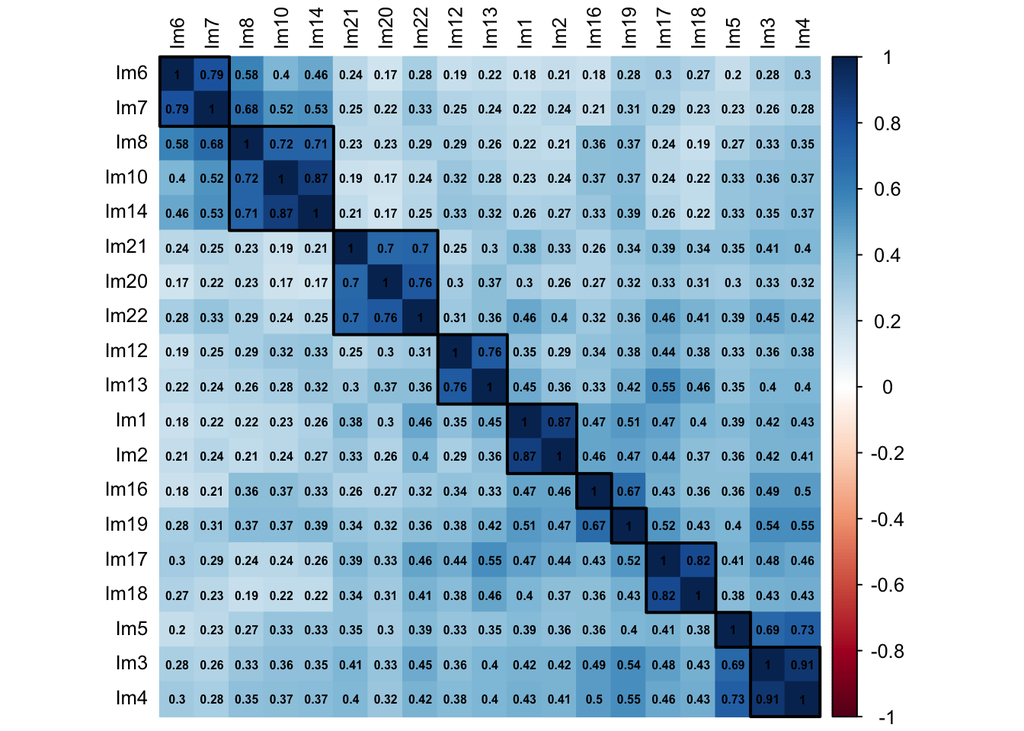

```r
#plot correlation matrix adjusting parameters to see previously identified groupings
corr_matrix <- cor(data_img_EFA2)
corrplot(as.matrix(corr_matrix),
         method = "color", #col = c("white","white","white","white","white", "lightgrey", "darkgrey", "black"),
         order = "hclust", addrect = 10, rect.col="black", # rect.col="red",
         addCoef.col = 'black', number.cex = .5,
         tl.col ="black",
         tl.cex = 0.80,
         )
```

Here we have excluded variables: *Im9, Im11, Im15* corresponding to *French Fashion, High-quality Cosmetics, Professional Selection of Brands* respectively

#### 2.2.3.2 Bartlett’s Test

```r
bart_spher(data_img_EFA2)
```

```
##  Bartlett's Test of Sphericity
##
## Call: bart_spher(x = data_img_EFA2)
##
##      X2 = 5743.675
##      df = 171
## p-value < 2.22e-16
```

The Bartlett Test tests the hypothesis that the sample originates from a population, where all variables are uncorrelated. This would not be good for factor analysis, we want this hypothesis to be rejected meaning p-value < 5%.

In our case we see that it is indeed rejected and that the data is not uncorrelated.

#### 2.2.3.3 KMO

```r
KMOTEST=KMOS(data_img_EFA2)
print(KMOTEST, sort=T)
```

```
##
## Kaiser-Meyer-Olkin Statistics
##
## Call: KMOS(x = data_img_EFA2)
##
## Measures of Sampling Adequacy (MSA):
##       Im2       Im1       Im6      Im20       Im7      Im10      Im14      Im13
## 0.7936280 0.7962594 0.8060329 0.8078449 0.8105719 0.8117583 0.8222647 0.8319415
##      Im18       Im4      Im12      Im17       Im3      Im22      Im16      Im21
## 0.8365582 0.8428568 0.8445115 0.8477624 0.8521646 0.8760949 0.8978889 0.9116457
##       Im8      Im19       Im5
## 0.9219319 0.9241605 0.9498660
##
## KMO-Criterion: 0.8507597
```

The KMO of 0.8507597 is above 0.6 which indicates the data is well suited for factor anlysis.

#### 2.2.3.4 Anti-image Correlation

```r
MSA_list <- data.table("Item"=names(KMOTEST$MSA), "MSA"=as.numeric(KMOTEST$MSA))

#Display table
MSA_list<- MSA_list |>
  setorder(cols = "MSA")

MSA_list |>
  kable() |>
  kable_minimal() |>
  row_spec(which(MSA_list[,2]<0.5), bold = T, color = "white", background = "#78BE20")
```

| Item | MSA |
| --- | --- |
| Im2 | 0.7936280 |
| Im1 | 0.7962594 |
| Im6 | 0.8060329 |
| Im20 | 0.8078449 |
| Im7 | 0.8105719 |
| Im10 | 0.8117583 |
| Im14 | 0.8222647 |
| Im13 | 0.8319415 |
| Im18 | 0.8365582 |
| Im4 | 0.8428568 |
| Im12 | 0.8445115 |
| Im17 | 0.8477624 |
| Im3 | 0.8521646 |
| Im22 | 0.8760949 |
| Im16 | 0.8978889 |
| Im21 | 0.9116457 |
| Im8 | 0.9219319 |
| Im19 | 0.9241605 |
| Im5 | 0.9498660 |

Here we have excluded variables: *Im9, Im11, Im15* corresponding to *French Fashion, High-quality Cosmetics, Professional Selection of Brands* respectively

Variables with MSA values above 0.5 are suited for factor analysis. Presence of items with low MSA’s (<0.5) could also indicate that an important topic hasn’t been well covered in the questionnaire.

All variables have MSA above 0.5

### 2.2.4 Select method: PCA

#### 2.2.4.1 Extract factors

```r
EFA_PC0 <- psych::principal(data_img_EFA2, rotate="varimax", scores=TRUE)
# note: by default number of factors = 1 if it is not specified
```

##### 2.2.4.1.1 Scree plot

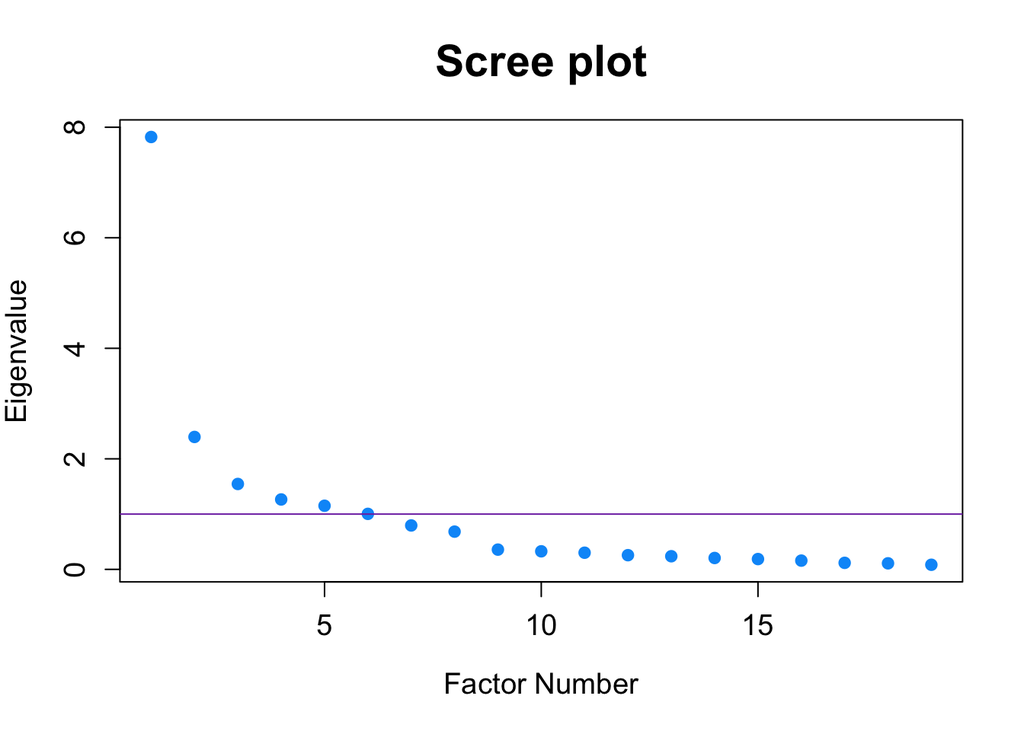

```r
#display Scree-plot
plot(EFA_PC0$values,xlab="Factor Number",
     ylab="Eigenvalue",
     main="Scree plot",
     cex.lab=1.2,
     cex.axis=1.2,
     cex.main=1.8,
     col = "#0099F8",
     pch = 19)
abline(h=1, col = "#7F35B2")
```

Here we have excluded variables: *Im9, Im11, Im15* corresponding to *French Fashion, High-quality Cosmetics, Professional Selection of Brands* respectively

##### 2.2.4.1.2 Kaiser Criterion

```r
EFA_PC0_kaiser_nb <- length(which(EFA_PC0$values > 1))
EFA_PC0_kaiser_nb
```

```
## [1] 6
```

The Kaiser criterion suggests we should retain factors with eigenvalues bigger than 1.

There are 6 factors satisfying this condition.

##### 2.2.4.1.3 Total Variance Explained

```r
#calculate total variance (does not change if number of factors change)
EFA_PC0_EigenValue <- EFA_PC0$values
EFA_PC0_Variance <- EFA_PC0_EigenValue / ncol(data_img_EFA2) * 100
EFA_PC0_SumVariance <- cumsum(EFA_PC0_EigenValue / ncol(data_img_EFA2))
EFA_PC0_Total_Variance_Explained <- cbind("Factor number"=
                                            seq(1, length.out=length(EFA_PC0_EigenValue[EFA_PC0_EigenValue>0])),
                                          EigenValue = EFA_PC0_EigenValue[EFA_PC0_EigenValue>0],
                                          Variance = EFA_PC0_Variance[EFA_PC0_EigenValue>0],
                                          Total_Variance = EFA_PC0_SumVariance[EFA_PC0_EigenValue>0])
#display table
EFA_PC0_Total_Variance_Explained |>
  kable() |>
  kable_minimal()
```

| Factor number | EigenValue | Variance | Total_Variance |
| --- | --- | --- | --- |
| 1 | 7.8236017 | 41.1768509 | 0.4117685 |
| 2 | 2.3958717 | 12.6098509 | 0.5378670 |
| 3 | 1.5450363 | 8.1317703 | 0.6191847 |
| 4 | 1.2648035 | 6.6568605 | 0.6857533 |
| 5 | 1.1508601 | 6.0571582 | 0.7463249 |
| 6 | 1.0040783 | 5.2846227 | 0.7991711 |
| 7 | 0.7944398 | 4.1812619 | 0.8409838 |
| 8 | 0.6826215 | 3.5927446 | 0.8769112 |
| 9 | 0.3572269 | 1.8801413 | 0.8957126 |
| 10 | 0.3265395 | 1.7186288 | 0.9128989 |
| 11 | 0.3010623 | 1.5845383 | 0.9287443 |
| 12 | 0.2565452 | 1.3502379 | 0.9422467 |
| 13 | 0.2374175 | 1.2495658 | 0.9547423 |
| 14 | 0.2056745 | 1.0824976 | 0.9655673 |
| 15 | 0.1862459 | 0.9802414 | 0.9753697 |
| 16 | 0.1581713 | 0.8324805 | 0.9836945 |
| 17 | 0.1177384 | 0.6196756 | 0.9898913 |
| 18 | 0.1090095 | 0.5737343 | 0.9956286 |
| 19 | 0.0830563 | 0.4371385 | 1.0000000 |

Here we have excluded variables: *Im9, Im11, Im15* corresponding to *French Fashion, High-quality Cosmetics, Professional Selection of Brands* respectively

With 6 factors we would explain 79.9171135% of total variance.

With 7 factors we would explain 84.0983754% of total variance.

```r
# test eigenvalue calculation
factorloadings = EFA_PC0$loadings[,1] # loadings 1st factor (default is nfactors = 1)
Eigenvalue = sum(factorloadings^2)
Eigenvalue
```

```
## [1] 7.823602
```

#### 2.2.4.2 Determine number of factors to retain

```r
# select nb of factors to test
nf = c(5,6,7,8)
```

#### 2.2.4.3 PCA orthogonal Varimax with n factors

```r
# perform multiple PCAs one for each factor number in selection
EFA_PCn = list()

i=1
for (n in nf) {
  # EFA_PCn[[i]] <- n
  EFA_PCn[[i]] <- psych::principal(data_img_EFA2, rotate="varimax", scores=TRUE, nfactors = n)
  i=i+1
}
names(EFA_PCn) <- nf
```

##### 2.2.4.3.1 Communalities

```r
#communalities for all selected number of factors

for (i in 1:length(nf)) {

  cat("###### Number of factors =", nf[[i]], "{.unnumbered}" ,"\n")

    EFA_PCn_communalities <- data.frame(sort(EFA_PCn[[i]]$communality))
    kbl <- EFA_PCn_communalities |>
              kable() |>
              kable_minimal() |>
              row_spec(which(EFA_PCn_communalities[,1]<.3), bold = T, color = "white", background = "#78BE20")

    print(kbl)
    cat("\n\n")

    # test communality calculation
    variableloading = EFA_PCn[[i]]$loadings["Im6",] # loadings 1st variable
    communality = sum(variableloading^2)
    print(paste0("Communality for Im6 =", communality))
    cat("\n")

}
```

###### Number of factors = 5

|  | sort.EFA_PCn..i…communality. |
| --- | --- |
| Im16 | 0.5627420 |
| Im19 | 0.6040097 |
| Im18 | 0.6043703 |
| Im6 | 0.6140708 |
| Im12 | 0.6996955 |
| Im17 | 0.7017673 |
| Im5 | 0.7187069 |
| Im10 | 0.7411953 |
| Im7 | 0.7503161 |
| Im14 | 0.7521760 |
| Im13 | 0.7676539 |
| Im21 | 0.7780934 |
| Im8 | 0.7945962 |
| Im20 | 0.7977385 |
| Im22 | 0.8302330 |
| Im1 | 0.8583742 |
| Im2 | 0.8595772 |
| Im3 | 0.8622026 |
| Im4 | 0.8826545 |

[1] “Communality for Im6 =0.614070750654582”

###### Number of factors = 6

|  | sort.EFA_PCn..i…communality. |
| --- | --- |
| Im16 | 0.5780901 |
| Im19 | 0.6044732 |
| Im5 | 0.7226160 |
| Im18 | 0.7796873 |
| Im21 | 0.7849607 |
| Im8 | 0.8001548 |
| Im6 | 0.8092549 |
| Im14 | 0.8138922 |
| Im10 | 0.8153406 |
| Im12 | 0.8180100 |
| Im13 | 0.8267182 |
| Im7 | 0.8273110 |
| Im17 | 0.8283716 |
| Im22 | 0.8339766 |
| Im20 | 0.8517294 |
| Im2 | 0.8599557 |
| Im1 | 0.8638266 |
| Im3 | 0.8723642 |
| Im4 | 0.8935184 |

[1] “Communality for Im6 =0.809254876875323”

###### Number of factors = 7

|  | sort.EFA_PCn..i…communality. |
| --- | --- |
| Im19 | 0.7273865 |
| Im5 | 0.7802051 |
| Im16 | 0.7819834 |
| Im21 | 0.7866942 |
| Im8 | 0.8062948 |
| Im14 | 0.8165173 |
| Im10 | 0.8293170 |
| Im18 | 0.8319009 |
| Im22 | 0.8341164 |
| Im6 | 0.8367586 |
| Im7 | 0.8515462 |
| Im12 | 0.8537636 |
| Im13 | 0.8636773 |
| Im20 | 0.8649849 |
| Im17 | 0.8656513 |
| Im3 | 0.8824406 |
| Im4 | 0.9094749 |
| Im2 | 0.9278606 |
| Im1 | 0.9281179 |

[1] “Communality for Im6 =0.836758575731983”

###### Number of factors = 8

|  | sort.EFA_PCn..i…communality. |
| --- | --- |
| Im21 | 0.7888867 |
| Im5 | 0.7984558 |
| Im8 | 0.8063886 |
| Im19 | 0.8081660 |
| Im22 | 0.8363504 |
| Im16 | 0.8608023 |
| Im20 | 0.8678176 |
| Im13 | 0.8781522 |
| Im3 | 0.8869270 |
| Im7 | 0.8888393 |
| Im12 | 0.8908851 |
| Im6 | 0.9020805 |
| Im17 | 0.9058821 |
| Im14 | 0.9068142 |
| Im4 | 0.9162386 |
| Im18 | 0.9224765 |
| Im10 | 0.9246341 |
| Im1 | 0.9352354 |
| Im2 | 0.9362803 |

[1] “Communality for Im6 =0.902080517143483”

Typically we should think about excluding variables with communalities below 0.3.

Based on the above, no variable should be excluded.

##### 2.2.4.3.2 Factor loadings

```r
# loadings for all selected number of factors

test = list()

for (i in 1:length(nf)) {

cat("###### Number of factors =", nf[[i]], "{.unnumbered}" ,"\n")

      # print(EFA_PCn[[i]]$loadings, cutoff=0.3)
      print(print_html(model_parameters(EFA_PCn[[i]], loadings=T, threshold = 0.3, summary=T)))

cat("\n\n")
}
```

###### Number of factors = 5

| Variable | RC2 | RC1 | RC4 | RC3 | RC5 | Complexity | Uniqueness |
| --- | --- | --- | --- | --- | --- | --- | --- |
| Im1 |  |  |  |  | 0.85 | 1.37 | 0.14 |
| Im2 |  |  |  |  | 0.88 | 1.22 | 0.14 |
| Im3 |  | 0.83 |  |  |  | 1.51 | 0.14 |
| Im4 |  | 0.85 |  |  |  | 1.48 | 0.12 |
| Im5 |  | 0.78 |  |  |  | 1.37 | 0.28 |
| Im6 | 0.74 |  |  |  |  | 1.22 | 0.39 |
| Im7 | 0.82 |  |  |  |  | 1.21 | 0.25 |
| Im8 | 0.86 |  |  |  |  | 1.14 | 0.21 |
| Im10 | 0.80 |  |  |  |  | 1.34 | 0.26 |
| Im12 |  |  | 0.79 |  |  | 1.26 | 0.30 |
| Im13 |  |  | 0.82 |  |  | 1.28 | 0.23 |
| Im14 | 0.81 |  |  |  |  | 1.32 | 0.25 |
| Im16 |  | 0.42 |  |  | 0.55 | 2.54 | 0.44 |
| Im17 |  |  | 0.69 |  | 0.33 | 2.03 | 0.30 |
| Im18 |  |  | 0.66 |  |  | 1.82 | 0.40 |
| Im19 |  | 0.41 | 0.30 |  | 0.51 | 3.27 | 0.40 |
| Im20 |  |  |  | 0.85 |  | 1.19 | 0.20 |
| Im21 |  |  |  | 0.83 |  | 1.29 | 0.22 |
| Im22 |  |  |  | 0.82 |  | 1.47 | 0.17 |

###### Number of factors = 6

| Variable | RC2 | RC1 | RC5 | RC3 | RC4 | RC6 | Complexity | Uniqueness |
| --- | --- | --- | --- | --- | --- | --- | --- | --- |
| Im1 |  |  | 0.86 |  |  |  | 1.34 | 0.14 |
| Im2 |  |  | 0.88 |  |  |  | 1.22 | 0.14 |
| Im3 |  | 0.85 |  |  |  |  | 1.45 | 0.13 |
| Im4 |  | 0.86 |  |  |  |  | 1.43 | 0.11 |
| Im5 |  | 0.79 |  |  |  |  | 1.33 | 0.28 |
| Im6 | 0.74 |  |  |  |  | 0.48 | 1.88 | 0.19 |
| Im7 | 0.82 |  |  |  |  | 0.35 | 1.49 | 0.17 |
| Im8 | 0.86 |  |  |  |  |  | 1.18 | 0.20 |
| Im10 | 0.79 |  |  |  |  |  | 1.63 | 0.18 |
| Im12 |  |  |  |  | 0.84 |  | 1.33 | 0.18 |
| Im13 |  |  |  |  | 0.80 |  | 1.63 | 0.17 |
| Im14 | 0.80 |  |  |  |  |  | 1.56 | 0.19 |
| Im16 |  | 0.41 | 0.57 |  |  |  | 2.43 | 0.42 |
| Im17 |  |  | 0.30 |  | 0.35 | 0.70 | 2.52 | 0.17 |
| Im18 |  |  |  |  | 0.31 | 0.73 | 2.01 | 0.22 |
| Im19 |  | 0.42 | 0.53 |  |  |  | 3.18 | 0.40 |
| Im20 |  |  |  | 0.89 |  |  | 1.18 | 0.15 |
| Im21 |  |  |  | 0.83 |  |  | 1.29 | 0.22 |
| Im22 |  |  |  | 0.83 |  |  | 1.48 | 0.17 |

###### Number of factors = 7

| Variable | RC2 | RC1 | RC3 | RC5 | RC6 | RC4 | RC7 | Complexity | Uniqueness |
| --- | --- | --- | --- | --- | --- | --- | --- | --- | --- |
| Im1 |  |  |  | 0.87 |  |  |  | 1.51 | 0.07 |
| Im2 |  |  |  | 0.89 |  |  |  | 1.34 | 0.07 |
| Im3 |  | 0.84 |  |  |  |  |  | 1.54 | 0.12 |
| Im4 |  | 0.86 |  |  |  |  |  | 1.50 | 0.09 |
| Im5 |  | 0.82 |  |  |  |  |  | 1.32 | 0.22 |
| Im6 | 0.80 |  |  |  | 0.34 |  |  | 1.66 | 0.16 |
| Im7 | 0.86 |  |  |  |  |  |  | 1.32 | 0.15 |
| Im8 | 0.83 |  |  |  |  |  |  | 1.33 | 0.19 |
| Im10 | 0.74 |  |  |  |  |  | 0.42 | 2.07 | 0.17 |
| Im12 |  |  |  |  |  | 0.86 |  | 1.33 | 0.15 |
| Im13 |  |  |  |  |  | 0.82 |  | 1.63 | 0.14 |
| Im14 | 0.76 |  |  |  |  |  | 0.36 | 1.91 | 0.18 |
| Im16 |  |  |  |  |  |  | 0.75 | 1.86 | 0.22 |
| Im17 |  |  |  |  | 0.78 |  |  | 1.93 | 0.13 |
| Im18 |  |  |  |  | 0.81 |  |  | 1.56 | 0.17 |
| Im19 |  |  |  |  | 0.32 |  | 0.62 | 3.09 | 0.27 |
| Im20 |  |  | 0.90 |  |  |  |  | 1.16 | 0.14 |
| Im21 |  |  | 0.83 |  |  |  |  | 1.28 | 0.21 |
| Im22 |  |  | 0.82 |  |  |  |  | 1.49 | 0.17 |

###### Number of factors = 8

| Variable | RC1 | RC3 | RC2 | RC8 | RC5 | RC4 | RC6 | RC7 | Complexity | Uniqueness |
| --- | --- | --- | --- | --- | --- | --- | --- | --- | --- | --- |
| Im1 |  |  |  |  | 0.87 |  |  |  | 1.52 | 0.06 |
| Im2 |  |  |  |  | 0.89 |  |  |  | 1.36 | 0.06 |
| Im3 | 0.83 |  |  |  |  |  |  |  | 1.62 | 0.11 |
| Im4 | 0.85 |  |  |  |  |  |  |  | 1.58 | 0.08 |
| Im5 | 0.82 |  |  |  |  |  |  |  | 1.40 | 0.20 |
| Im6 |  |  |  | 0.90 |  |  |  |  | 1.22 | 0.10 |
| Im7 |  |  | 0.35 | 0.85 |  |  |  |  | 1.50 | 0.11 |
| Im8 |  |  | 0.69 | 0.50 |  |  |  |  | 2.24 | 0.19 |
| Im10 |  |  | 0.91 |  |  |  |  |  | 1.24 | 0.08 |
| Im12 |  |  |  |  |  | 0.88 |  |  | 1.32 | 0.11 |
| Im13 |  |  |  |  |  | 0.83 |  |  | 1.58 | 0.12 |
| Im14 |  |  | 0.89 |  |  |  |  |  | 1.32 | 0.09 |
| Im16 |  |  |  |  |  |  |  | 0.83 | 1.56 | 0.14 |
| Im17 |  |  |  |  |  |  | 0.81 |  | 1.84 | 0.09 |
| Im18 |  |  |  |  |  |  | 0.88 |  | 1.40 | 0.08 |
| Im19 |  |  |  |  |  |  |  | 0.74 | 2.14 | 0.19 |
| Im20 |  | 0.90 |  |  |  |  |  |  | 1.17 | 0.13 |
| Im21 |  | 0.83 |  |  |  |  |  |  | 1.29 | 0.21 |
| Im22 |  | 0.82 |  |  |  |  |  |  | 1.51 | 0.16 |

Here we have excluded variables: *Im9, Im11, Im15* corresponding to *French Fashion, High-quality Cosmetics, Professional Selection of Brands* respectively

Factor loadings:

- Number of items per factor >=3
  - this condition is respected in all cases except when we have 8 factors. We eliminate the 8 factor solution
- 0.40–0.30–0.20 rule: satisfactory variables (a) load onto their primary factor above 0.40, (b) load onto alter-native factors below 0.30, and (c) demonstrate a difference of 0.20 between their primary and alternative factor loadings.
  - 5 factor solution:
    - this condition is not respected for many variables. We eliminate the 5 factor solution
  - 6 factor solution:
    - this condition is not respected for: Im6, Im7, Im9, (Im11), (Im15), Im16, Im17, Im18, Im19 where Im17 and Im18 are particularly spread out
  - 7 factor solution:
    - this condition is not respected for: Im7, Im8, Im9, Im15, Im16, Im19 where Im16 and Im19 are particularly spread out

Based on the above we will prefer the **7 factor solution** but we will no doubt have to exclude some variables, potentially 19 as it also has the lower communality than Im16 and probably also factor 9 as it also has low communality

Thurstone simple structure criteria:

- Each row (variable) of the factor pattern matrix should have at least one zero
- Each column (factor) should have at least r zero elements, and the zeros for one factor should be unique from the zeros for the other factors
- For every pair of columns (factors), there should be at least r variables with a zero coefficient in one column and a non-zero coefficient in the other
- When r > 3 every pair of columns (factors), should contain a large proportion of variables with zeros in both columns
- For every pair of columns (factors), there should be only a small proportion of variables with non-zeros in both columns

#### 2.2.4.4 PCA oblique Promax with n factors

```r
# perform multiple PCAs one for each factor number in selection
EFA_PCn_obl = list()

i=1
for (n in nf) {
  # EFA_PCn_obl[[i]] <- n
  EFA_PCn_obl[[i]] <- psych::principal(data_img_EFA2, rotate="promax", scores=TRUE, nfactors = n)
  i=i+1
}
names(EFA_PCn_obl) <- nf

length(EFA_PCn_obl)
```

```
## [1] 4
```

##### 2.2.4.4.1 Communalities

```r
#communalities for all selected number of factors

for (i in 1:length(nf)) {

  cat("###### Number of factors =", nf[[i]], "{.unnumbered}" ,"\n")

    EFA_PCn_obl_communalities <- data.frame(sort(EFA_PCn_obl[[i]]$communality))
    kbl <- EFA_PCn_obl_communalities |>
              kable() |>
              kable_minimal() |>
              row_spec(which(EFA_PCn_obl_communalities[,1]<.3), bold = T, color = "white", background = "#78BE20")

    print(kbl)
    cat("\n\n")

    # test communality calculation
    variableloading = EFA_PCn_obl[[i]]$loadings["Im6",] # loadings 1st variable
    communality = sum(variableloading^2)
    print(paste0("Communality for Im6 =", communality))
    cat("\n")

}
```

###### Number of factors = 5

|  | sort.EFA_PCn_obl..i…communality. |
| --- | --- |
| Im16 | 0.5627420 |
| Im19 | 0.6040097 |
| Im18 | 0.6043703 |
| Im6 | 0.6140708 |
| Im12 | 0.6996955 |
| Im17 | 0.7017673 |
| Im5 | 0.7187069 |
| Im10 | 0.7411953 |
| Im7 | 0.7503161 |
| Im14 | 0.7521760 |
| Im13 | 0.7676539 |
| Im21 | 0.7780934 |
| Im8 | 0.7945962 |
| Im20 | 0.7977385 |
| Im22 | 0.8302330 |
| Im1 | 0.8583742 |
| Im2 | 0.8595772 |
| Im3 | 0.8622026 |
| Im4 | 0.8826545 |

[1] “Communality for Im6 =0.674515165355013”

###### Number of factors = 6

|  | sort.EFA_PCn_obl..i…communality. |
| --- | --- |
| Im16 | 0.5780901 |
| Im19 | 0.6044732 |
| Im5 | 0.7226160 |
| Im18 | 0.7796873 |
| Im21 | 0.7849607 |
| Im8 | 0.8001548 |
| Im6 | 0.8092549 |
| Im14 | 0.8138922 |
| Im10 | 0.8153406 |
| Im12 | 0.8180100 |
| Im13 | 0.8267182 |
| Im7 | 0.8273110 |
| Im17 | 0.8283716 |
| Im22 | 0.8339766 |
| Im20 | 0.8517294 |
| Im2 | 0.8599557 |
| Im1 | 0.8638266 |
| Im3 | 0.8723642 |
| Im4 | 0.8935184 |

[1] “Communality for Im6 =0.866138105524558”

###### Number of factors = 7

|  | sort.EFA_PCn_obl..i…communality. |
| --- | --- |
| Im19 | 0.7273865 |
| Im5 | 0.7802051 |
| Im16 | 0.7819834 |
| Im21 | 0.7866942 |
| Im8 | 0.8062948 |
| Im14 | 0.8165173 |
| Im10 | 0.8293170 |
| Im18 | 0.8319009 |
| Im22 | 0.8341164 |
| Im6 | 0.8367586 |
| Im7 | 0.8515462 |
| Im12 | 0.8537636 |
| Im13 | 0.8636773 |
| Im20 | 0.8649849 |
| Im17 | 0.8656513 |
| Im3 | 0.8824406 |
| Im4 | 0.9094749 |
| Im2 | 0.9278606 |
| Im1 | 0.9281179 |

[1] “Communality for Im6 =1.00508497746007”

###### Number of factors = 8

|  | sort.EFA_PCn_obl..i…communality. |
| --- | --- |
| Im21 | 0.7888867 |
| Im5 | 0.7984558 |
| Im8 | 0.8063886 |
| Im19 | 0.8081660 |
| Im22 | 0.8363504 |
| Im16 | 0.8608023 |
| Im20 | 0.8678176 |
| Im13 | 0.8781522 |
| Im3 | 0.8869270 |
| Im7 | 0.8888393 |
| Im12 | 0.8908851 |
| Im6 | 0.9020805 |
| Im17 | 0.9058821 |
| Im14 | 0.9068142 |
| Im4 | 0.9162386 |
| Im18 | 0.9224765 |
| Im10 | 0.9246341 |
| Im1 | 0.9352354 |
| Im2 | 0.9362803 |

[1] “Communality for Im6 =1.07424942160987”

##### 2.2.4.4.2 Factor loadings

```r
# loadings for all selected number of factors

test = list()

for (i in 1:length(nf)) {

cat("###### Number of factors =", nf[[i]], "{.unnumbered}" ,"\n")

      # print(EFA_PCn_obl[[i]]$loadings, cutoff=0.3)
      print(print_html(model_parameters(EFA_PCn_obl[[i]], loadings=T, threshold = 0.3, summary=T)))

cat("\n\n")
}
```

###### Number of factors = 5

| Variable | RC2 | RC1 | RC4 | RC5 | RC3 | Complexity | Uniqueness |
| --- | --- | --- | --- | --- | --- | --- | --- |
| Im1 |  |  |  | 0.99 |  | 1.05 | 0.14 |
| Im2 |  |  |  | 1.05 |  | 1.05 | 0.14 |
| Im3 |  | 0.94 |  |  |  | 1.02 | 0.14 |
| Im4 |  | 0.96 |  |  |  | 1.02 | 0.12 |
| Im5 |  | 0.91 |  |  |  | 1.06 | 0.28 |
| Im6 | 0.79 |  |  |  |  | 1.19 | 0.39 |
| Im7 | 0.87 |  |  |  |  | 1.21 | 0.25 |
| Im8 | 0.90 |  |  |  |  | 1.01 | 0.21 |
| Im10 | 0.81 |  |  |  |  | 1.18 | 0.26 |
| Im12 |  |  | 0.93 |  |  | 1.10 | 0.30 |
| Im13 |  |  | 0.94 |  |  | 1.02 | 0.23 |
| Im14 | 0.82 |  |  |  |  | 1.12 | 0.25 |
| Im16 |  | 0.32 |  | 0.52 |  | 1.87 | 0.44 |
| Im17 |  |  | 0.70 |  |  | 1.17 | 0.30 |
| Im18 |  |  | 0.69 |  |  | 1.11 | 0.40 |
| Im19 |  |  |  | 0.44 |  | 2.13 | 0.40 |
| Im20 |  |  |  |  | 0.89 | 1.02 | 0.20 |
| Im21 |  |  |  |  | 0.85 | 1.06 | 0.22 |
| Im22 |  |  |  |  | 0.82 | 1.05 | 0.17 |

###### Number of factors = 6

| Variable | RC2 | RC1 | RC5 | RC3 | RC4 | RC6 | Complexity | Uniqueness |
| --- | --- | --- | --- | --- | --- | --- | --- | --- |
| Im1 |  |  | 0.99 |  |  |  | 1.07 | 0.14 |
| Im2 |  |  | 1.04 |  |  |  | 1.07 | 0.14 |
| Im3 |  | 0.97 |  |  |  |  | 1.04 | 0.13 |
| Im4 |  | 0.99 |  |  |  |  | 1.04 | 0.11 |
| Im5 |  | 0.93 |  |  |  |  | 1.06 | 0.28 |
| Im6 | 0.78 |  |  |  |  | 0.45 | 1.85 | 0.19 |
| Im7 | 0.86 |  |  |  |  |  | 1.36 | 0.17 |
| Im8 | 0.89 |  |  |  |  |  | 1.02 | 0.20 |
| Im10 | 0.80 |  |  |  |  |  | 1.39 | 0.18 |
| Im12 |  |  |  |  | 0.94 |  | 1.13 | 0.18 |
| Im13 |  |  |  |  | 0.88 |  | 1.25 | 0.17 |
| Im14 | 0.81 |  |  |  |  |  | 1.30 | 0.19 |
| Im16 |  |  | 0.54 |  |  |  | 1.68 | 0.42 |
| Im17 |  |  |  |  |  | 0.73 | 1.45 | 0.17 |
| Im18 |  |  |  |  |  | 0.77 | 1.33 | 0.22 |
| Im19 |  |  | 0.45 |  |  |  | 2.09 | 0.40 |
| Im20 |  |  |  | 0.94 |  |  | 1.08 | 0.15 |
| Im21 |  |  |  | 0.85 |  |  | 1.04 | 0.22 |
| Im22 |  |  |  | 0.82 |  |  | 1.05 | 0.17 |

###### Number of factors = 7

| Variable | RC2 | RC1 | RC3 | RC5 | RC4 | RC6 | RC7 | Complexity | Uniqueness |
| --- | --- | --- | --- | --- | --- | --- | --- | --- | --- |
| Im1 |  |  |  | 0.93 |  |  |  | 1.06 | 0.07 |
| Im2 |  |  |  | 0.97 |  |  |  | 1.05 | 0.07 |
| Im3 |  | 0.90 |  |  |  |  |  | 1.02 | 0.12 |
| Im4 |  | 0.93 |  |  |  |  |  | 1.01 | 0.09 |
| Im5 |  | 0.94 |  |  |  |  |  | 1.06 | 0.22 |
| Im6 | 0.90 |  |  |  |  |  |  | 1.48 | 0.16 |
| Im7 | 0.95 |  |  |  |  |  |  | 1.19 | 0.15 |
| Im8 | 0.83 |  |  |  |  |  |  | 1.17 | 0.19 |
| Im10 | 0.67 |  |  |  |  |  | 0.35 | 1.89 | 0.17 |
| Im12 |  |  |  |  | 0.95 |  |  | 1.06 | 0.15 |
| Im13 |  |  |  |  | 0.90 |  |  | 1.18 | 0.14 |
| Im14 | 0.70 |  |  |  |  |  |  | 1.64 | 0.18 |
| Im16 |  |  |  |  |  |  | 0.89 | 1.24 | 0.22 |
| Im17 |  |  |  |  |  | 0.83 |  | 1.23 | 0.13 |
| Im18 |  |  |  |  |  | 0.89 |  | 1.19 | 0.17 |
| Im19 |  |  |  |  |  | 0.30 | 0.71 | 1.48 | 0.27 |
| Im20 |  |  | 0.98 |  |  |  |  | 1.06 | 0.14 |
| Im21 |  |  | 0.87 |  |  |  |  | 1.03 | 0.21 |
| Im22 |  |  | 0.83 |  |  |  |  | 1.04 | 0.17 |

###### Number of factors = 8

| Variable | RC1 | RC3 | RC2 | RC8 | RC5 | RC6 | RC4 | RC7 | Complexity | Uniqueness |
| --- | --- | --- | --- | --- | --- | --- | --- | --- | --- | --- |
| Im1 |  |  |  |  | 0.94 |  |  |  | 1.01 | 0.06 |
| Im2 |  |  |  |  | 0.99 |  |  |  | 1.01 | 0.06 |
| Im3 | 0.89 |  |  |  |  |  |  |  | 1.05 | 0.11 |
| Im4 | 0.92 |  |  |  |  |  |  |  | 1.05 | 0.08 |
| Im5 | 0.92 |  |  |  |  |  |  |  | 1.15 | 0.20 |
| Im6 |  |  |  | 1.02 |  |  |  |  | 1.05 | 0.10 |
| Im7 |  |  |  | 0.91 |  |  |  |  | 1.04 | 0.11 |
| Im8 |  |  | 0.59 | 0.37 |  |  |  |  | 1.93 | 0.19 |
| Im10 |  |  | 1.01 |  |  |  |  |  | 1.03 | 0.08 |
| Im12 |  |  |  |  |  |  | 0.97 |  | 1.02 | 0.11 |
| Im13 |  |  |  |  |  |  | 0.88 |  | 1.03 | 0.12 |
| Im14 |  |  | 0.97 |  |  |  |  |  | 1.02 | 0.09 |
| Im16 |  |  |  |  |  |  |  | 0.95 | 1.04 | 0.14 |
| Im17 |  |  |  |  |  | 0.88 |  |  | 1.02 | 0.09 |
| Im18 |  |  |  |  |  | 1.01 |  |  | 1.01 | 0.08 |
| Im19 |  |  |  |  |  |  |  | 0.80 | 1.04 | 0.19 |
| Im20 |  | 0.99 |  |  |  |  |  |  | 1.09 | 0.13 |
| Im21 |  | 0.88 |  |  |  |  |  |  | 1.04 | 0.21 |
| Im22 |  | 0.84 |  |  |  |  |  |  | 1.06 | 0.16 |

Here we have excluded variables: *Im9, Im11, Im15* corresponding to *French Fashion, High-quality Cosmetics, Professional Selection of Brands* respectively

## 2.3 Confirmatory factor analysis

We test whether the constructs found in the exploratory phase adequately describe what is going on.

### 2.3.1 First model

```r
CFA_model_img <- "
FOOD =~ Im8 + Im10 + Im14
BRAND =~ Im16 + Im17 + Im18 + Im19
CHOICE =~ Im1 + Im2 + Im15
ATMOS =~ Im20 + Im21 + Im22
DECO =~ Im3 + Im4 + Im5
QUAL =~ Im11 + Im12 + Im13
FRENCH =~ Im6 + Im7 + Im9
"

# CFA_fit_img <- cfa(CFA_model_img, data=data_img_EFA, missing="ML")
CFA_fit_img <- cfa(CFA_model_img, data=survey, missing="ML")

summary(CFA_fit_img, fit.measures=TRUE, standardized=TRUE)
```

```
## lavaan 0.6.15 ended normally after 115 iterations
##
##   Estimator                                         ML
##   Optimization method                           NLMINB
##   Number of model parameters                        87
##
##   Number of observations                           553
##   Number of missing patterns                        87
##
## Model Test User Model:
##
##   Test statistic                              1068.090
##   Degrees of freedom                               188
##   P-value (Chi-square)                           0.000
##
## Model Test Baseline Model:
##
##   Test statistic                              8838.959
##   Degrees of freedom                               231
##   P-value                                        0.000
##
## User Model versus Baseline Model:
##
##   Comparative Fit Index (CFI)                    0.898
##   Tucker-Lewis Index (TLI)                       0.874
##
##   Robust Comparative Fit Index (CFI)             0.898
##   Robust Tucker-Lewis Index (TLI)                0.875
##
## Loglikelihood and Information Criteria:
##
##   Loglikelihood user model (H0)             -15292.450
##   Loglikelihood unrestricted model (H1)     -14758.405
##
##   Akaike (AIC)                               30758.900
##   Bayesian (BIC)                             31134.336
##   Sample-size adjusted Bayesian (SABIC)      30858.160
##
## Root Mean Square Error of Approximation:
##
```

[output cut: 132 more lines]

```
##    .Im4               0.109    0.024    4.492    0.000    0.109    0.060
##    .Im5               0.744    0.049   15.193    0.000    0.744    0.420
##    .Im11              0.812    0.055   14.807    0.000    0.812    0.621
##    .Im12              0.307    0.039    7.793    0.000    0.307    0.238
##    .Im13              0.394    0.044    8.861    0.000    0.394    0.272
##    .Im6               0.443    0.041   10.739    0.000    0.443    0.308
##    .Im7               0.218    0.042    5.247    0.000    0.218    0.150
##    .Im9               1.204    0.080   15.054    0.000    1.204    0.660
##     FOOD              0.600    0.062    9.748    0.000    1.000    1.000
##     BRAND             0.415    0.067    6.158    0.000    1.000    1.000
##     CHOICE            1.627    0.110   14.723    0.000    1.000    1.000
##     ATMOS             1.600    0.138   11.629    0.000    1.000    1.000
##     DECO              1.528    0.107   14.314    0.000    1.000    1.000
##     QUAL              0.496    0.067    7.382    0.000    1.000    1.000
##     FRENCH            0.997    0.088   11.288    0.000    1.000    1.000
```

#### 2.3.1.1 Discussion of global fit measures

Chi square: p-value > 0.05

RMSEA RMSEA <= 0.05 Good fit 0.05 < RMSEA <= 0.08 Acceptable fit 0.08 < RMSEA <= 0.10 Bad fit RMSEA > 0.1 Unacceptable fit

CFI CFI < 0.90 definitely reject model 0.90 < CFI < 0.95 high underrejection rates for misspecified models CFI > 0.95 accept model

#### 2.3.1.2 local fit measures

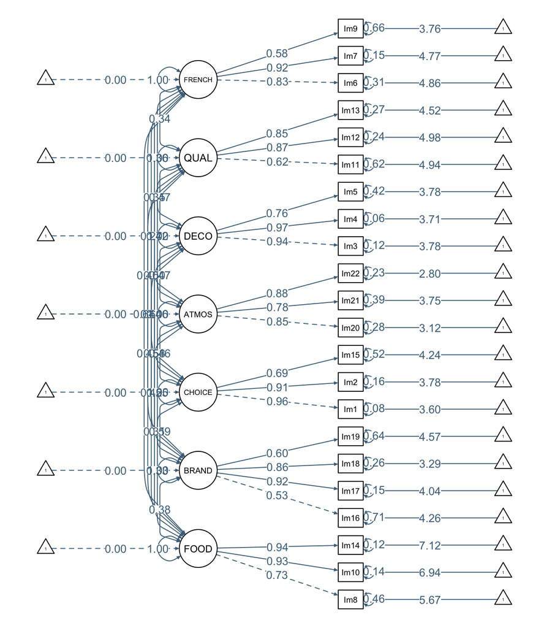

```r
# semPaths(CFA_fit_img, what = "path", whatLabels = "std", style = "mx",
#          rotation = 2, layout = "tree3", mar = c(1, 2, 1, 2),
#          nCharNodes = 7,shapeMan = "rectangle", sizeMan = 8, sizeMan2 = 5,
#          curvePivot=TRUE, edge.label.cex = 1.2, edge.color = "skyblue4")


semPaths(CFA_fit_img, what = "path", whatLabels = "std", style = "mx",
         rotation = 2, layout = "tree3", mar = c(1, 2, 1, 2),
         nCharNodes = 7,shapeMan = "rectangle",
         sizeMan = 4, sizeMan2 = 3, sizeInt = 2, sizeLat = 6, asize = 1.5,
         curvePivot=TRUE, edge.label.cex = .8, edge.color = "skyblue4"
         )
```

```r
lambda = inspect(CFA_fit_img, what="std")$lambda
theta = inspect(CFA_fit_img, what="std")$theta

# create lambda matrix with ones instead of std.all
ones <- lambda
ones[ones>0] <- 1

# a matrix with dimensions of lambda matrix but with lambdas replaced by thetas
theta_lb <- theta %*% ones
```

##### 2.3.1.2.1 Indicator reliability criterion

```r
# calculate indicator reliabilities (should be larger than 0.4)
indicrel <- lambda^2/(lambda^2 + theta_lb)
# indicrel

# replace all values satisfying condition with NaN for visibility
indicrel_fail <- indicrel
indicrel_fail[indicrel_fail>.4] <- NaN
indicrel_fail
```

```
##      FOOD BRAND CHOICE ATMOS DECO  QUAL FRENCH
## Im8   NaN   NaN    NaN   NaN  NaN   NaN    NaN
## Im10  NaN   NaN    NaN   NaN  NaN   NaN    NaN
## Im14  NaN   NaN    NaN   NaN  NaN   NaN    NaN
## Im16  NaN 0.285    NaN   NaN  NaN   NaN    NaN
## Im17  NaN   NaN    NaN   NaN  NaN   NaN    NaN
## Im18  NaN   NaN    NaN   NaN  NaN   NaN    NaN
## Im19  NaN 0.361    NaN   NaN  NaN   NaN    NaN
## Im1   NaN   NaN    NaN   NaN  NaN   NaN    NaN
## Im2   NaN   NaN    NaN   NaN  NaN   NaN    NaN
## Im15  NaN   NaN    NaN   NaN  NaN   NaN    NaN
## Im20  NaN   NaN    NaN   NaN  NaN   NaN    NaN
## Im21  NaN   NaN    NaN   NaN  NaN   NaN    NaN
## Im22  NaN   NaN    NaN   NaN  NaN   NaN    NaN
## Im3   NaN   NaN    NaN   NaN  NaN   NaN    NaN
## Im4   NaN   NaN    NaN   NaN  NaN   NaN    NaN
## Im5   NaN   NaN    NaN   NaN  NaN   NaN    NaN
## Im11  NaN   NaN    NaN   NaN  NaN 0.379    NaN
## Im12  NaN   NaN    NaN   NaN  NaN   NaN    NaN
## Im13  NaN   NaN    NaN   NaN  NaN   NaN    NaN
## Im6   NaN   NaN    NaN   NaN  NaN   NaN    NaN
## Im7   NaN   NaN    NaN   NaN  NaN   NaN    NaN
## Im9   NaN   NaN    NaN   NaN  NaN   NaN   0.34
```

##### 2.3.1.2.2 Construct reliability criterion

```r
# calculate construct reliability (should be above .6)
constrrel <- (t(lambda) %*% ones)^2 / ((t(lambda) %*% ones)^2 + t(theta_lb) %*% ones )
# constrrel

# replace all values satisfying condition with NaN for visibility
constrrel_fail <- constrrel
constrrel_fail[constrrel_fail>.6] <- NaN
constrrel_fail
```

```
##        FOOD BRAND CHOICE ATMOS DECO QUAL FRENCH
## FOOD    NaN   NaN    NaN   NaN  NaN  NaN    NaN
## BRAND   NaN   NaN    NaN   NaN  NaN  NaN    NaN
## CHOICE  NaN   NaN    NaN   NaN  NaN  NaN    NaN
## ATMOS   NaN   NaN    NaN   NaN  NaN  NaN    NaN
## DECO    NaN   NaN    NaN   NaN  NaN  NaN    NaN
## QUAL    NaN   NaN    NaN   NaN  NaN  NaN    NaN
## FRENCH  NaN   NaN    NaN   NaN  NaN  NaN    NaN
```

##### 2.3.1.2.3 Average Variance Extracted criterion

```r
# calculate Average Variance Extracted (should be above .5)
AVE <- (t(lambda) %*% lambda) / (t(lambda) %*% lambda + t(theta_lb) %*% ones )
# avgvar

# replace all values satisfying condition with NaN for visibility
AVE_fail <- AVE
AVE_fail[AVE_fail>.5] <- NaN
AVE_fail
```

```
##        FOOD BRAND CHOICE ATMOS DECO QUAL FRENCH
## FOOD    NaN   NaN    NaN   NaN  NaN  NaN    NaN
## BRAND   NaN   NaN    NaN   NaN  NaN  NaN    NaN
## CHOICE  NaN   NaN    NaN   NaN  NaN  NaN    NaN
## ATMOS   NaN   NaN    NaN   NaN  NaN  NaN    NaN
## DECO    NaN   NaN    NaN   NaN  NaN  NaN    NaN
## QUAL    NaN   NaN    NaN   NaN  NaN  NaN    NaN
## FRENCH  NaN   NaN    NaN   NaN  NaN  NaN    NaN
```

##### 2.3.1.2.4 Fornell-Larcker Criteria

```r
# correlations between constructs (factors...) should be lower than .7
psi = inspect(CFA_fit_img, what="std")$psi
psi_fail <- psi
psi_fail[psi_fail<.7] <- NaN
psi_fail
```

```
##        FOOD BRAND CHOICE ATMOS DECO QUAL FRENCH
## FOOD      1
## BRAND   NaN     1
## CHOICE  NaN   NaN      1
## ATMOS   NaN   NaN    NaN     1
## DECO    NaN   NaN    NaN   NaN    1
## QUAL    NaN   NaN    NaN   NaN  NaN    1
## FRENCH  NaN   NaN    NaN   NaN  NaN  NaN      1
```

```r
# AVE should be higher than squared correlations between constructs

# replace diagonal of psi matrix with AVE values
psi2 <- psi - psi * diag(1,nrow(psi),ncol(psi)) + diag(AVE) * diag(1,nrow(AVE),ncol(AVE))

# create matrix with columns filled with AVE
AVE_full <- AVE
AVE_full[is.na(AVE_full)] <- 0 #replace NAs with 0s
AVE_full <- AVE_full^0 %*% AVE_full # multiply a matrix full of ones with AVE_full to get columns filled with AVE

# substract matrices any psi bigger than AVE will be negative
AVEpsi_fail <- AVE_full - psi2
# AVE_full - psi2
AVEpsi_fail[AVEpsi_fail >= 0] <- NaN

AVE_full
```

```
##             FOOD     BRAND    CHOICE     ATMOS      DECO      QUAL    FRENCH
## FOOD   0.7592164 0.5585631 0.7449731 0.6989967 0.7989017 0.6232432 0.6276946
## BRAND  0.7592164 0.5585631 0.7449731 0.6989967 0.7989017 0.6232432 0.6276946
## CHOICE 0.7592164 0.5585631 0.7449731 0.6989967 0.7989017 0.6232432 0.6276946
## ATMOS  0.7592164 0.5585631 0.7449731 0.6989967 0.7989017 0.6232432 0.6276946
## DECO   0.7592164 0.5585631 0.7449731 0.6989967 0.7989017 0.6232432 0.6276946
## QUAL   0.7592164 0.5585631 0.7449731 0.6989967 0.7989017 0.6232432 0.6276946
## FRENCH 0.7592164 0.5585631 0.7449731 0.6989967 0.7989017 0.6232432 0.6276946
```

```r
psi
```

```
##         FOOD BRAND CHOICE ATMOS  DECO  QUAL FRENCH
## FOOD   1.000
## BRAND  0.379 1.000
## CHOICE 0.327 0.594  1.000
## ATMOS  0.307 0.553  0.462 1.000
## DECO   0.423 0.583  0.462 0.467 1.000
## QUAL   0.453 0.598  0.495 0.418 0.471 1.000
## FRENCH 0.636 0.396  0.266 0.352 0.361 0.339  1.000
```

```r
AVEpsi_fail
```

```
##          FOOD  BRAND CHOICE  ATMOS   DECO   QUAL FRENCH
## FOOD        .
## BRAND     NaN      .
## CHOICE    NaN -0.035      .
## ATMOS     NaN    NaN    NaN      .
## DECO      NaN -0.024    NaN    NaN      .
## QUAL      NaN -0.039    NaN    NaN    NaN      .
## FRENCH    NaN    NaN    NaN    NaN    NaN    NaN      .
```

#### 2.3.1.3 Modification indices

```r
arrange(modificationindices(CFA_fit_img),-mi)
```

```
##        lhs op  rhs      mi    epc sepc.lv sepc.all sepc.nox
## 1     Im17 ~~ Im18 297.079  1.047   1.047    3.027    3.027
## 2     Im16 ~~ Im19 146.951  0.515   0.515    0.561    0.561
## 3   FRENCH =~  Im8 128.001  0.534   0.533    0.504    0.504
## 4      Im1 ~~  Im2 104.934  0.906   0.906    4.543    4.543
## 5     Im10 ~~ Im14  83.261  0.289   0.289    2.974    2.974
## 6    BRAND =~ Im15  74.902  0.704   0.454    0.378    0.378
## 7     QUAL =~  Im9  74.216  0.699   0.492    0.364    0.364
## 8     QUAL =~ Im15  72.993  0.595   0.419    0.349    0.349
## 9    BRAND =~  Im9  62.008  0.702   0.452    0.335    0.335
## 10    DECO =~ Im19  61.275  0.332   0.411    0.365    0.365
## 11     Im8 ~~  Im7  52.691  0.168   0.168    0.499    0.499
## 12    DECO =~ Im15  48.200  0.252   0.311    0.260    0.260
## 13    FOOD =~ Im19  46.374  0.399   0.309    0.275    0.275
## 14  CHOICE =~ Im16  45.285  0.321   0.410    0.340    0.340
```

[output cut: 349 more lines]

### 2.3.2 Second model

Based on the modification indices we create a new model

```r
CFA_model_img <- "
FOOD =~ Im10 + Im14
BRAND =~ Im17 + Im18
PROF =~ Im16 + Im19
CHOICE =~ Im1 + Im2 + Im15
ATMOS =~ Im20 + Im21 + Im22
DECO =~ Im3 + Im4 + Im5
QUAL =~ Im11 + Im12 + Im13
FRENCH =~ Im6 + Im7 + Im8 + Im9
"

CFA_fit_img <- cfa(CFA_model_img, data=survey, missing="ML")
summary(CFA_fit_img, fit.measures=TRUE, standardized=TRUE)
```

```
## lavaan 0.6.15 ended normally after 109 iterations
##
##   Estimator                                         ML
##   Optimization method                           NLMINB
##   Number of model parameters                        94
##
##   Number of observations                           553
##   Number of missing patterns                        87
##
## Model Test User Model:
##
##   Test statistic                               712.812
##   Degrees of freedom                               181
##   P-value (Chi-square)                           0.000
##
## Model Test Baseline Model:
##
##   Test statistic                              8838.959
##   Degrees of freedom                               231
##   P-value                                        0.000
##
## User Model versus Baseline Model:
##
##   Comparative Fit Index (CFI)                    0.938
##   Tucker-Lewis Index (TLI)                       0.921
##
##   Robust Comparative Fit Index (CFI)             0.938
##   Robust Tucker-Lewis Index (TLI)                0.921
##
## Loglikelihood and Information Criteria:
##
##   Loglikelihood user model (H0)             -15114.811
##   Loglikelihood unrestricted model (H1)     -14758.405
##
##   Akaike (AIC)                               30417.622
##   Bayesian (BIC)                             30823.265
##   Sample-size adjusted Bayesian (SABIC)      30524.868
##
## Root Mean Square Error of Approximation:
##
```

[output cut: 143 more lines]

```
##    .Im11              0.814    0.055   14.805    0.000    0.814    0.622
##    .Im12              0.309    0.039    7.835    0.000    0.309    0.239
##    .Im13              0.391    0.044    8.800    0.000    0.391    0.270
##    .Im6               0.497    0.039   12.594    0.000    0.497    0.346
##    .Im7               0.253    0.035    7.268    0.000    0.253    0.174
##    .Im8               0.462    0.035   13.011    0.000    0.462    0.413
##    .Im9               1.197    0.078   15.284    0.000    1.197    0.656
##     FOOD              0.662    0.049   13.559    0.000    1.000    1.000
##     BRAND             1.455    0.104   14.033    0.000    1.000    1.000
##     PROF              0.855    0.088    9.711    0.000    1.000    1.000
##     CHOICE            1.616    0.110   14.687    0.000    1.000    1.000
##     ATMOS             1.599    0.138   11.618    0.000    1.000    1.000
##     DECO              1.527    0.107   14.326    0.000    1.000    1.000
##     QUAL              0.495    0.067    7.368    0.000    1.000    1.000
##     FRENCH            0.941    0.085   11.049    0.000    1.000    1.000
```

#### 2.3.2.1 Discussion of global fit measures

Chi square: p-value > 0.05

RMSEA RMSEA <= 0.05 Good fit 0.05 < RMSEA <= 0.08 Acceptable fit 0.08 < RMSEA <= 0.10 Bad fit RMSEA > 0.1 Unacceptable fit

CFI CFI < 0.90 definitely reject model 0.90 < CFI < 0.95 high underrejection rates for misspecified models CFI > 0.95 accept model

#### 2.3.2.2 local fit measures

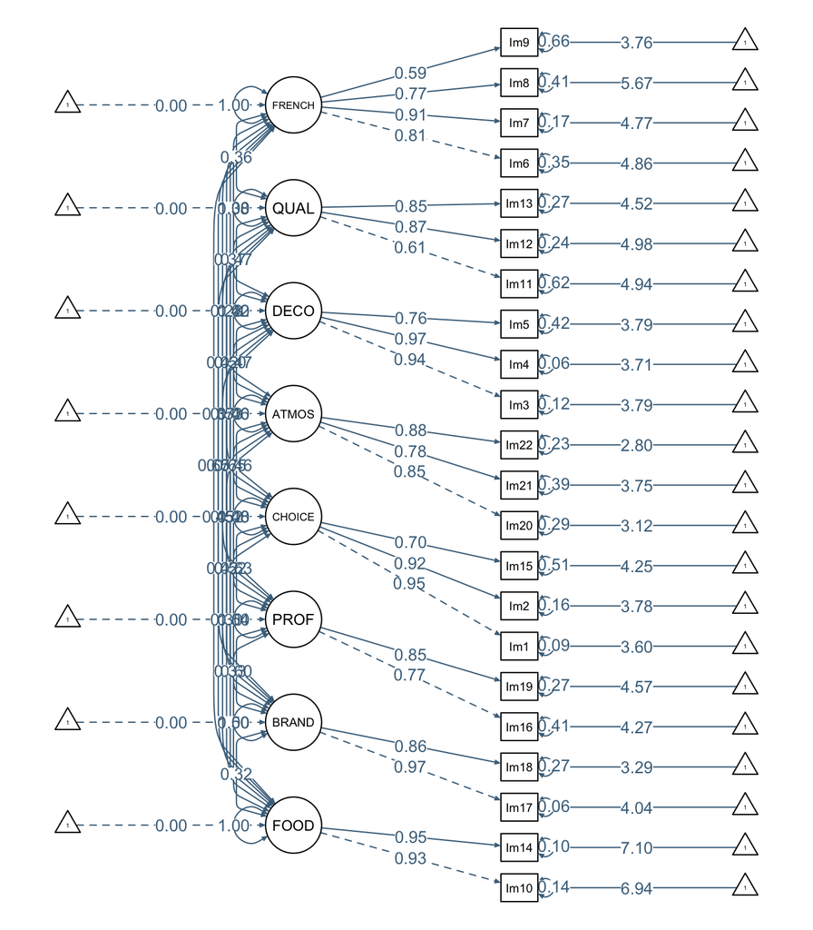

```r
# semPaths(CFA_fit_img, what = "path", whatLabels = "std", style = "mx",
#          rotation = 2, layout = "tree3", mar = c(1, 2, 1, 2),
#          nCharNodes = 7,shapeMan = "rectangle", sizeMan = 8, sizeMan2 = 5,
#          curvePivot=TRUE, edge.label.cex = 1.2, edge.color = "skyblue4")


semPaths(CFA_fit_img, what = "path", whatLabels = "std", style = "mx",
         rotation = 2, layout = "tree3", mar = c(1, 2, 1, 2),
         nCharNodes = 7,shapeMan = "rectangle",
         sizeMan = 4, sizeMan2 = 3, sizeInt = 2, sizeLat = 6, asize = 1.5,
         curvePivot=TRUE, edge.label.cex = .8, edge.color = "skyblue4"
         )
```

```r
lambda = inspect(CFA_fit_img, what="std")$lambda
theta = inspect(CFA_fit_img, what="std")$theta

# create lambda matrix with ones instead of std.all
ones <- lambda
ones[ones>0] <- 1

# a matrix with dimensions of lambda matrix but with lambdas replaced by thetas
theta_lb <- theta %*% ones
```

##### 2.3.2.2.1 Indicator reliability criterion

```r
# calculate indicator reliabilities (should be larger than 0.4)
indicrel <- lambda^2/(lambda^2 + theta_lb)
# indicrel

# replace all values satisfying condition with NaN for visibility
indicrel_fail <- indicrel
indicrel_fail[indicrel_fail>.4] <- NaN
indicrel_fail
```

```
##      FOOD BRAND PROF CHOICE ATMOS DECO  QUAL FRENCH
## Im10  NaN   NaN  NaN    NaN   NaN  NaN   NaN    NaN
## Im14  NaN   NaN  NaN    NaN   NaN  NaN   NaN    NaN
## Im17  NaN   NaN  NaN    NaN   NaN  NaN   NaN    NaN
## Im18  NaN   NaN  NaN    NaN   NaN  NaN   NaN    NaN
## Im16  NaN   NaN  NaN    NaN   NaN  NaN   NaN    NaN
## Im19  NaN   NaN  NaN    NaN   NaN  NaN   NaN    NaN
## Im1   NaN   NaN  NaN    NaN   NaN  NaN   NaN    NaN
## Im2   NaN   NaN  NaN    NaN   NaN  NaN   NaN    NaN
## Im15  NaN   NaN  NaN    NaN   NaN  NaN   NaN    NaN
## Im20  NaN   NaN  NaN    NaN   NaN  NaN   NaN    NaN
## Im21  NaN   NaN  NaN    NaN   NaN  NaN   NaN    NaN
## Im22  NaN   NaN  NaN    NaN   NaN  NaN   NaN    NaN
## Im3   NaN   NaN  NaN    NaN   NaN  NaN   NaN    NaN
## Im4   NaN   NaN  NaN    NaN   NaN  NaN   NaN    NaN
## Im5   NaN   NaN  NaN    NaN   NaN  NaN   NaN    NaN
## Im11  NaN   NaN  NaN    NaN   NaN  NaN 0.378    NaN
## Im12  NaN   NaN  NaN    NaN   NaN  NaN   NaN    NaN
## Im13  NaN   NaN  NaN    NaN   NaN  NaN   NaN    NaN
## Im6   NaN   NaN  NaN    NaN   NaN  NaN   NaN    NaN
## Im7   NaN   NaN  NaN    NaN   NaN  NaN   NaN    NaN
## Im8   NaN   NaN  NaN    NaN   NaN  NaN   NaN    NaN
## Im9   NaN   NaN  NaN    NaN   NaN  NaN   NaN  0.344
```

##### 2.3.2.2.2 Construct reliability criterion

```r
# calculate construct reliability (should be above .6)
constrrel <- (t(lambda) %*% ones)^2 / ((t(lambda) %*% ones)^2 + t(theta_lb) %*% ones )
# constrrel

# replace all values satisfying condition with NaN for visibility
constrrel_fail <- constrrel
constrrel_fail[constrrel_fail>.6] <- NaN
constrrel_fail
```

```
##        FOOD BRAND PROF CHOICE ATMOS DECO QUAL FRENCH
## FOOD    NaN   NaN  NaN    NaN   NaN  NaN  NaN    NaN
## BRAND   NaN   NaN  NaN    NaN   NaN  NaN  NaN    NaN
## PROF    NaN   NaN  NaN    NaN   NaN  NaN  NaN    NaN
## CHOICE  NaN   NaN  NaN    NaN   NaN  NaN  NaN    NaN
## ATMOS   NaN   NaN  NaN    NaN   NaN  NaN  NaN    NaN
## DECO    NaN   NaN  NaN    NaN   NaN  NaN  NaN    NaN
## QUAL    NaN   NaN  NaN    NaN   NaN  NaN  NaN    NaN
## FRENCH  NaN   NaN  NaN    NaN   NaN  NaN  NaN    NaN
```

##### 2.3.2.2.3 Average Variance Extracted criterion

```r
# calculate Average Variance Extracted (should be above .5)
AVE <- (t(lambda) %*% lambda) / (t(lambda) %*% lambda + t(theta_lb) %*% ones )
# avgvar

# replace all values satisfying condition with NaN for visibility
AVE_fail <- AVE
AVE_fail[AVE_fail>.5] <- NaN
AVE_fail
```

```
##        FOOD BRAND PROF CHOICE ATMOS DECO QUAL FRENCH
## FOOD    NaN   NaN  NaN    NaN   NaN  NaN  NaN    NaN
## BRAND   NaN   NaN  NaN    NaN   NaN  NaN  NaN    NaN
## PROF    NaN   NaN  NaN    NaN   NaN  NaN  NaN    NaN
## CHOICE  NaN   NaN  NaN    NaN   NaN  NaN  NaN    NaN
## ATMOS   NaN   NaN  NaN    NaN   NaN  NaN  NaN    NaN
## DECO    NaN   NaN  NaN    NaN   NaN  NaN  NaN    NaN
## QUAL    NaN   NaN  NaN    NaN   NaN  NaN  NaN    NaN
## FRENCH  NaN   NaN  NaN    NaN   NaN  NaN  NaN    NaN
```

##### 2.3.2.2.4 Fornell-Larcker Criteria

```r
# correlations between constructs (factors...) should be lower than .7
psi = inspect(CFA_fit_img, what="std")$psi
psi_fail <- psi
psi_fail[psi_fail<.7] <- NaN
psi_fail
```

```
##        FOOD BRAND PROF CHOICE ATMOS DECO QUAL FRENCH
## FOOD      1
## BRAND   NaN     1
## PROF    NaN   NaN    1
## CHOICE  NaN   NaN  NaN      1
## ATMOS   NaN   NaN  NaN    NaN     1
## DECO    NaN   NaN  NaN    NaN   NaN    1
## QUAL    NaN   NaN  NaN    NaN   NaN  NaN    1
## FRENCH  NaN   NaN  NaN    NaN   NaN  NaN  NaN      1
```

```r
# AVE should be higher than squared correlations between constructs

# replace diagonal of psi matrix with AVE values
psi2 <- psi - psi * diag(1,nrow(psi),ncol(psi)) + diag(AVE) * diag(1,nrow(AVE),ncol(AVE))

# create matrix with columns filled with AVE
AVE_full <- AVE
AVE_full[is.na(AVE_full)] <- 0 #replace NAs with 0s
AVE_full <- AVE_full^0 %*% AVE_full # multiply a matrix full of ones with AVE_full to get columns filled with AVE

# substract matrices, replace all values satisfying positive condition (AVE > psi) with NaN
AVEpsi_fail <- AVE_full - psi2
# AVE_full - psi2
AVEpsi_fail[AVEpsi_fail >= 0] <- NaN

AVE_full
```

```
##            FOOD    BRAND      PROF    CHOICE     ATMOS      DECO      QUAL
## FOOD   0.879396 0.836154 0.6591628 0.7460967 0.6989483 0.7983609 0.6230634
## BRAND  0.879396 0.836154 0.6591628 0.7460967 0.6989483 0.7983609 0.6230634
## PROF   0.879396 0.836154 0.6591628 0.7460967 0.6989483 0.7983609 0.6230634
## CHOICE 0.879396 0.836154 0.6591628 0.7460967 0.6989483 0.7983609 0.6230634
## ATMOS  0.879396 0.836154 0.6591628 0.7460967 0.6989483 0.7983609 0.6230634
## DECO   0.879396 0.836154 0.6591628 0.7460967 0.6989483 0.7983609 0.6230634
## QUAL   0.879396 0.836154 0.6591628 0.7460967 0.6989483 0.7983609 0.6230634
## FRENCH 0.879396 0.836154 0.6591628 0.7460967 0.6989483 0.7983609 0.6230634
##          FRENCH
## FOOD   0.603095
## BRAND  0.603095
## PROF   0.603095
## CHOICE 0.603095
## ATMOS  0.603095
## DECO   0.603095
## QUAL   0.603095
## FRENCH 0.603095
```

```r
psi
```

```
##         FOOD BRAND  PROF CHOICE ATMOS  DECO  QUAL FRENCH
## FOOD   1.000
## BRAND  0.325 1.000
## PROF   0.499 0.601 1.000
## CHOICE 0.329 0.543 0.632  1.000
## ATMOS  0.295 0.516 0.479  0.462 1.000
## DECO   0.417 0.516 0.654  0.462 0.467 1.000
## QUAL   0.452 0.566 0.529  0.496 0.418 0.471 1.000
## FRENCH 0.668 0.369 0.423  0.280 0.366 0.381 0.365  1.000
```

```r
AVEpsi_fail
```

```
##          FOOD  BRAND   PROF CHOICE  ATMOS   DECO   QUAL FRENCH
## FOOD        .
## BRAND     NaN      .
## PROF      NaN    NaN      .
## CHOICE    NaN    NaN    NaN      .
## ATMOS     NaN    NaN    NaN    NaN      .
## DECO      NaN    NaN    NaN    NaN    NaN      .
## QUAL      NaN    NaN    NaN    NaN    NaN    NaN      .
## FRENCH    NaN    NaN    NaN    NaN    NaN    NaN    NaN      .
```

#### 2.3.2.3 Modification indices

```r
arrange(modificationindices(CFA_fit_img),-mi)
```

```
##        lhs op  rhs      mi    epc sepc.lv sepc.all sepc.nox
## 1      Im1 ~~  Im2 131.201  0.922   0.922    4.504    4.504
## 2     FOOD =~  Im8 121.236  0.670   0.546    0.516    0.516
## 3     PROF =~ Im15 108.692  0.658   0.608    0.507    0.507
## 4      Im6 ~~  Im7  87.853  0.387   0.387    1.091    1.091
## 5     QUAL =~ Im15  72.264  0.590   0.415    0.346    0.346
## 6     QUAL =~  Im9  66.547  0.667   0.469    0.347    0.347
## 7    BRAND =~  Im9  56.011  0.341   0.411    0.304    0.304
## 8    BRAND =~ Im15  55.278  0.296   0.357    0.298    0.298
## 9     DECO =~ Im15  48.624  0.252   0.311    0.260    0.260
## 10   ATMOS =~ Im15  38.305  0.230   0.291    0.243    0.243
## 11  FRENCH =~ Im15  38.068  0.268   0.260    0.217    0.217
## 12     Im6 ~~  Im8  29.856 -0.168  -0.168   -0.351   -0.351
## 13    FOOD =~  Im7  27.248 -0.355  -0.289   -0.239   -0.239
## 14    FOOD =~  Im6  27.073 -0.350  -0.285   -0.238   -0.238
```

[output cut: 368 more lines]

### 2.3.3 Factor scores for path analysis

```r
## don't actually think we need this as we can use the full data for confirmatory and path analysis
# data_img_EFA2
# data.frame(EFA_PCn[[3]]$scores)
#
# numcol_data_img_EFA = dim(data_img_EFA2)[2]
# numcol_scores = dim(EFA_PCn[[3]]$scores)[2]
# numcol_data_img_EFA
# numcol_scores
#
# CFA_data = cbind(data_img_EFA2, EFA_PCn[[3]]$scores, survey_excl_img2["SAT_1"])
# CFA_data
# # colnames(CFA_data)[23:29] = c("Gourmet food", "Brand image", "Choice range", "Relaxed atmosphere", "Decoration", "Product quality", "Frenchness")
#
# # colnames(CFA_data)[numcol_data_img_EFA:(numcol_data_img_EFA + numcol_scores)] = c("FOOD", "BRAND", "CHOICE", "ATMOS", "DECO")
# colnames(CFA_data)[numcol_data_img_EFA:(numcol_data_img_EFA + numcol_scores)] = c("FOOD", "BRAND", "CHOICE", "ATMOS", "DECO", "QUAL", "FRENCH")
#
# CFA_data
```

### 2.3.4 model

```r
# model_SAT_1 <-"
# SAT_1 ~ Im1 + Im2 + Im3 + Im4 + Im5 + Im6 + Im7 + Im8 + Im9 + Im10 + Im11 + Im12 + Im13 + Im14 + Im15 + Im16 + Im17 + Im18 + Im19 + Im20 + Im21 + Im22
# "

model_SAT_1 <-"
FOOD =~ Im8 + Im10 + Im14
BRAND =~ Im16 + Im17 + Im18 + Im19
CHOICE =~ Im1 + Im2 + Im15
ATMOS =~ Im20 + Im21 + Im22
DECO =~ Im3 + Im4 + Im5
QUAL =~ Im11 + Im12 + Im13
FRENCH =~ Im6 + Im7 + Im9
SAT_1 ~ FOOD + BRAND + CHOICE + ATMOS + DECO + QUAL + FRENCH
"

# model_SAT_1 <-"SAT_1 ~ ."
```

### 2.3.5 linear regression

```r
# # linear regression
# lm_SAT_1 <-  lm (model_SAT_1, data = survey)
# summary(lm_SAT_1)
# # note: lm deletes all missing variables in the Xs! (not in Ys) (see help lavOptions)
```

### 2.3.6 path analysis

```r
# path analysis
cfa_SAT_1 <- cfa(model_SAT_1, data=survey, missing="ML")
summary(cfa_SAT_1, fit.measures=TRUE, standardized=TRUE)
```

```
## lavaan 0.6.15 ended normally after 119 iterations
##
##   Estimator                                         ML
##   Optimization method                           NLMINB
##   Number of model parameters                        96
##
##   Number of observations                           553
##   Number of missing patterns                        88
##
## Model Test User Model:
##
##   Test statistic                              1097.064
##   Degrees of freedom                               203
##   P-value (Chi-square)                           0.000
##
## Model Test Baseline Model:
##
##   Test statistic                              9026.244
##   Degrees of freedom                               253
##   P-value                                        0.000
##
## User Model versus Baseline Model:
##
##   Comparative Fit Index (CFI)                    0.898
##   Tucker-Lewis Index (TLI)                       0.873
##
##   Robust Comparative Fit Index (CFI)             0.898
##   Robust Tucker-Lewis Index (TLI)                0.873
##
## Loglikelihood and Information Criteria:
##
##   Loglikelihood user model (H0)             -16001.864
##   Loglikelihood unrestricted model (H1)     -15453.332
##
##   Akaike (AIC)                               32195.727
##   Bayesian (BIC)                             32610.002
##   Sample-size adjusted Bayesian (SABIC)      32305.255
##
## Root Mean Square Error of Approximation:
##
```

[output cut: 145 more lines]

```
##    .Im5               0.744    0.049   15.193    0.000    0.744    0.420
##    .Im11              0.813    0.055   14.812    0.000    0.813    0.621
##    .Im12              0.306    0.039    7.759    0.000    0.306    0.237
##    .Im13              0.394    0.044    8.870    0.000    0.394    0.272
##    .Im6               0.442    0.041   10.746    0.000    0.442    0.307
##    .Im7               0.219    0.041    5.285    0.000    0.219    0.150
##    .Im9               1.205    0.080   15.066    0.000    1.205    0.660
##    .SAT_1             0.769    0.047   16.296    0.000    0.769    0.739
##     FOOD              0.601    0.062    9.761    0.000    1.000    1.000
##     BRAND             0.421    0.068    6.169    0.000    1.000    1.000
##     CHOICE            1.628    0.110   14.767    0.000    1.000    1.000
##     ATMOS             1.601    0.138   11.628    0.000    1.000    1.000
##     DECO              1.528    0.107   14.311    0.000    1.000    1.000
##     QUAL              0.496    0.067    7.382    0.000    1.000    1.000
##     FRENCH            0.997    0.088   11.298    0.000    1.000    1.000
```

```r
# note: cfa deletes all missing variables in the Xs! (not in Ys) (see help lavOptions)
```